# Social Control - Pushing Separate

Pascal Küng, MSc, Patrick Höhener, MSc, James M. Allen, PhD, Robert Tobias, PhD, Urte Scholz, PhD

2025-08-14

```r
knitr::opts_chunk$set(echo = TRUE)

rm(list = ls())

#cmdstanr::set_cmdstan_path(path = "C:/Users/kueng/.cmdstan/cmdstan-2.35.0")
#cmdstanr::set_cmdstan_path(path = "C:/Users/pascku/.cmdstan/cmdstan-2.36.0")

library(tidyverse)
library(R.utils)
library(wbCorr)
library(readxl)
library(kableExtra)
library(brms)
library(bayesplot)
library(see)
library(beepr)
library(DHARMa)
library(digest)




source(file.path('Functions', 'ReportModels.R'))
source(file.path('Functions', 'PrettyTables.R'))
source(file.path('Functions', 'ReportMeasures.R'))
source(file.path('Functions', 'PrepareData.R'))

report_function_hash <- digest::digest(summarize_brms)
```

```r
system("shutdown /a")
```

```
## [1] 1116
```

```r
# Set options for analysis
use_mi = FALSE
shutdown = FALSE
report_ordinal = FALSE
do_priorsense = FALSE
get_bayesfactor = FALSE
check_models = TRUE #

if (get_bayesfactor) {
  stats_to_report <- c('CI', 'SE', 'pd', 'ROPE', 'BF', 'Rhat', 'ESS')
} else {
  stats_to_report <- c('CI', 'SE', 'pd', 'ROPE', 'Rhat', 'ESS')
}

options(
  dplyr.print_max = 100,
  brms.backend = 'cmdstan',
  brms.file_refit = ifelse(use_mi, 'never', 'on_change'),
  brms.file_refit = 'on_change',
  #brms.file_refit = 'always',
  error = function() {
    beepr::beep(sound = 5)
    if (shutdown) {
      system("shutdown /s /t 180")
      quit(save = "no", status = 1)
    }
  }
  , es.use_symbols = TRUE
)


####################### Model parameters #######################

iterations = 12000 # 12'000 per chain to achieve 40'000
warmup = 2000 # 2000

# NO AR!!!
#corstr = 'ar'
#corstr = 'cosy_couple'
#corstr = 'cosy_couple:user'


################################################################

suffix_nopushing = paste0('_SensitivityNoPushing_', as.character(iterations))
suffix_onlypushing = paste0('_SensitivityOnlyPushing_', as.character(iterations))
```

```r
df <- openxlsx::read.xlsx(file.path('long.xlsx'))
df_original <- df

df_double <- prepare_data(df, recode_pushing = FALSE, use_mi = use_mi)[[1]]
```

Constructing scales reshaping data (4field) centering data within and between

```r
summary(df_double$pushing)
```

Min. 1st Qu. Median Mean 3rd Qu. Max. NA’s 0.0000 0.0000 0.0000 0.3468 0.0000 5.0000 2323

# Modelling

```r
# For indistinguishable Dyads
model_rows_fixed <- c(
    'Intercept',
    # '-- WITHIN PERSON MAIN EFFECTS --',
    'persuasion_self_cw',
    'persuasion_partner_cw',
    'pressure_self_cw',
    'pressure_partner_cw',
    'pushing_self_cw',
    'pushing_partner_cw',
    'day',
    'plan_selfPlan',
    'plan_partnerPlan',
    'weartime_self_cw',

    # '-- BETWEEN PERSON MAIN EFFECTS',
    'persuasion_self_cb',
    'persuasion_partner_cb',
    'pressure_self_cb',
    'pressure_partner_cb',
    'pushing_self_cb',
    'pushing_partner_cb',
    'weartime_self_cb'
  )


model_rows_fixed_ordinal <- c(
  model_rows_fixed[1],
  'Intercept[1]',
  'Intercept[2]',
  'Intercept[3]',
  'Intercept[4]',
  'Intercept[5]',
  model_rows_fixed[2:length(model_rows_fixed)]
)

model_rows_random <- c(
  # '--------------',
  'coupleID: sd(Intercept)',

  'coupleID:userID: sd(Intercept)',
  'coupleID:userID: sd(persuasion_self_cw)',
  'coupleID:userID: sd(persuasion_partner_cw)',
  'coupleID:userID: sd(pressure_self_cw)',
  'coupleID:userID: sd(pressure_partner_cw)',
  'coupleID:userID: sd(pushing_self_cw)',
  'coupleID:userID: sd(pushing_partner_cw)',

  # '-- CORRELATION STRUCTURE -- ',
  'sigma'
)

model_rows_random_ordinal <- c(model_rows_random,'disc')
```

```r
# For indistinguishable Dyads
model_rownames_fixed <- c(
    "Intercept",
    # "-- WITHIN PERSON MAIN EFFECTS --",
    "Daily individual's experienced persuasion",
    "Daily partner's experienced persuasion",
    "Daily individual's experienced pressure",
    "Daily partner's experienced pressure",
    "Daily individual's experienced pushing",
    "Daily partner's experienced pushing",
    "Day",
    "Own action plan",
    'Partner action plan',
    "Daily wear time",

    # "-- BETWEEN PERSON MAIN EFFECTS",
    "Mean individual's experienced persuasion",
    "Mean partner's experienced persuasion",
    "Mean individual's experienced pressure",
    "Mean partner's experienced pressure",
    "Mean individual's experienced pushing",
    "Mean partner's experienced pushing",
    "Mean wear time"
  )


model_rownames_fixed_ordinal <- c(
  model_rownames_fixed[1],
  'Intercept[1]',
  'Intercept[2]',
  'Intercept[3]',
  'Intercept[4]',
  'Intercept[5]',
  model_rownames_fixed[2:length(model_rownames_fixed)]
)


model_rownames_random <- c(
  # '--------------',
  # '-- RANDOM EFFECTS L3 --',
  'L3:sd(Intercept)',


  'L2:sd(Intercept)',
  "L2:sd(Daily individual's experienced persuasion)",
  "L2:sd(Daily partner's experienced persuasion)", # OR partner received
  "L2:sd(Daily individual's experienced pressure)",
  "L2:sd(Daily partner's experienced pressure)",
  "L2:sd(Daily individual's experienced pushing)",
  "L2:sd(Daily partner's experienced pushing)",

  # '-- CORRELATION STRUCTURE L1 -- ',
  'sigma'
)

model_rownames_random_ordinal <- c(model_rownames_random,'disc')
```

```r
rows_to_pack <- list(
  "Within-Person Effects" = c(2,11),
  "Between-Person Effects" = c(12,18),
  "Random Effects (Level 3 - Couple)" = c(19, 19),
  "Random Effects (Level 2 - Couple:Person)" = c(20, 26),
  "Additional Parameters" = c(27,27)
  )


rows_to_pack_ordinal <- list(
  "Within-Person Effects" = c(2+5,11+5),
  "Between-Person Effects" = c(12+5,18+5),
  "Random Effects (Level 3 - Couple)" = c(19+5, 19+5),
  "Random Effects (Level 2 - Couple:Person)" = c(20+5, 26+5),
  "Additional Parameters" = c(27+5,27+6)
  )
```

# WITHOUT PUSHING

## Self-Reported MVPA

### Hurdle Lognormal Model

```r
formula <- bf(
  pa_sub ~
    persuasion_self_cw + persuasion_partner_cw +
    pressure_self_cw + pressure_partner_cw +

    persuasion_self_cb + persuasion_partner_cb +
    pressure_self_cb + pressure_partner_cb +

    plan_self + plan_partner +
    day +

    # Random effects
    (1 | dd | coupleID)

  + (1 + persuasion_self_cw + persuasion_partner_cw +
    pressure_self_cw + pressure_partner_cw | d_u | coupleID:userID),

  hu = ~ persuasion_self_cw + persuasion_partner_cw +
    pressure_self_cw + pressure_partner_cw +

    persuasion_self_cb + persuasion_partner_cb +
    pressure_self_cb + pressure_partner_cb +

    plan_self + plan_partner +
    day +

    # Random effects
    (1 | dd | coupleID)

  + (1 + persuasion_self_cw + persuasion_partner_cw +
    pressure_self_cw + pressure_partner_cw | d_u | coupleID:userID)

  , decomp = 'QR'
  #, autocor = autocor_str
)

prior1 <- c(
  brms::set_prior("normal(0, 2.5)", class = "b")
  , brms::set_prior("normal(0, 2)", class = "b", dpar = "hu")
  , brms::set_prior("normal(0, 50)", class = "Intercept") # for non-zero PA
  , brms::set_prior("normal(0.5, 2.5)", class = "Intercept", dpar = 'hu') # hurdle part
  , brms::set_prior("normal(0, 2)", class = "sd", group = "coupleID", lb = 0)
  , brms::set_prior("student_t(3, 0, 2.5)", class = "sigma", lb = 0)
)

#brms::validate_prior(
#  prior1,
#  formula = formula,
#  data = df_double,
#  family = hurdle_lognormal()
#)

#df_minimal <- df_double[, c("AorB", all.vars(as.formula(formula)))]

pa_sub <- my_brm(
  mi = use_mi,
  imputed_data = implist,

  formula = formula,
  prior = prior1,
  data = df_double,
  family = brms::hurdle_lognormal(),
  #family = brms::hurdle_negbinomial(),
  #family = brms::hurdle_poisson(),
  #control = list(adapt_delta = 0.95, max_treedepth = 15),
  iter = iterations,
  warmup = warmup,
  chains = 4,
  cores = 4,
  seed = 42,
  file = file.path("models_cache_brms", paste0("pa_sub_hu_lognormal", suffix_nopushing))
  #, file_refit = 'always'
)
pa_sub_digest <- digest::digest(pa_sub)
```

```r
# rope range for continuous part of the model
rope_factor <- sd(log(pa_sub$data$pa_sub[pa_sub$data$pa_sub > 0]))
rope_range_continuous = c(-0.1 * rope_factor, 0.1 * rope_factor)

summary_pa_sub <- summarize_brms(
  pa_sub,
  stats_to_report = stats_to_report,
  rope_range = rope_range_continuous,
  hu_rope_range = c(-0.18, 0.18),
  model_rows_fixed = model_rows_fixed,
  model_rows_random = model_rows_random,
  model_rownames_fixed = model_rownames_fixed,
  model_rownames_random = model_rownames_random,
  exponentiate = T)
# Print the updated dataframe
summary_pa_sub %>%
  print_df(rows_to_pack = rows_to_pack)
```

|  | exp(Est.)_hu | SE_hu | 95% CI_hu | pd_hu | ROPE_hu | inside ROPE_hu | Rhat_hu | Bulk_ESS_hu | Tail_ESS_hu | exp(Est.)_nonzero | SE_nonzero | 95% CI_nonzero | pd_nonzero | ROPE_nonzero | inside ROPE_nonzero | Rhat_nonzero | Bulk_ESS_nonzero | Tail_ESS_nonzero |
| --- | --- | --- | --- | --- | --- | --- | --- | --- | --- | --- | --- | --- | --- | --- | --- | --- | --- | --- |
| Intercept | 0.21*** | 0.04 | [ 0.15, 0.29] | 1.000 | [0.84, 1.20] | 0.000 | 1.000 | 27552 | 30150 | 37.02*** | 3.11 | [31.30, 43.69] | 1.000 | [0.92, 1.08] | 0.000 | 1.000 | 18213 | 23727 |
| **Within-Person Effects** |  |  |  |  |  |  |  |  |  |  |  |  |  |  |  |  |  |  |
| Daily individual’s experienced persuasion | 1.60*** | 0.12 | [ 1.38, 1.89] | 1.000 | [0.84, 1.20] | 0.000 | 1.000 | 34431 | 28363 | 1.03 | 0.02 | [ 0.98, 1.08] | 0.894 | [0.92, 1.08] | 0.979 | 1.000 | 31928 | 31584 |
| Daily partner’s experienced persuasion | 1.40*** | 0.10 | [ 1.22, 1.64] | 1.000 | [0.84, 1.20] | 0.013 | 1.000 | 37503 | 29456 | 1.02 | 0.02 | [ 0.98, 1.06] | 0.848 | [0.92, 1.08] | 0.998 | 1.000 | 44275 | 33785 |
| Daily individual’s experienced pressure | 1.06 | 0.20 | [ 0.74, 1.72] | 0.633 | [0.84, 1.20] | 0.640 | 1.000 | 31947 | 23599 | 0.89* | 0.05 | [ 0.80, 0.99] | 0.988 | [0.92, 1.08] | 0.252 | 1.000 | 39775 | 34559 |
| Daily partner’s experienced pressure | 1.96** | 0.53 | [ 1.27, 4.37] | 0.999 | [0.84, 1.20] | 0.013 | 1.000 | 19569 | 19160 | 0.94 | 0.04 | [ 0.85, 1.02] | 0.938 | [0.92, 1.08] | 0.605 | 1.000 | 39118 | 37670 |
| Daily individual’s experienced pushing | NA | NA | NA | NA | NA | NA | NA | NA | NA | NA | NA | NA | NA | NA | NA | NA | NA | NA |
| Daily partner’s experienced pushing | NA | NA | NA | NA | NA | NA | NA | NA | NA | NA | NA | NA | NA | NA | NA | NA | NA | NA |
| Day | 0.78 | 0.12 | [ 0.58, 1.05] | 0.946 | [0.84, 1.20] | 0.325 | 1.000 | 66229 | 29417 | 0.95 | 0.06 | [ 0.85, 1.07] | 0.788 | [0.92, 1.08] | 0.672 | 1.000 | 67689 | 31235 |
| Own action plan | 10.71*** | 1.13 | [ 8.73, 13.21] | 1.000 | [0.84, 1.20] | 0.000 | 1.000 | 55383 | 31496 | 1.36*** | 0.07 | [ 1.23, 1.49] | 1.000 | [0.92, 1.08] | 0.000 | 1.000 | 63182 | 29252 |
| Partner action plan | 1.27* | 0.13 | [ 1.04, 1.56] | 0.991 | [0.84, 1.20] | 0.271 | 1.000 | 55193 | 30223 | 1.06 | 0.05 | [ 0.97, 1.15] | 0.912 | [0.92, 1.08] | 0.688 | 1.000 | 60854 | 30401 |
| Daily wear time | NA | NA | NA | NA | NA | NA | NA | NA | NA | NA | NA | NA | NA | NA | NA | NA | NA | NA |
| **Between-Person Effects** |  |  |  |  |  |  |  |  |  |  |  |  |  |  |  |  |  |  |
| Mean individual’s experienced persuasion | 1.79 | 0.69 | [ 0.83, 3.82] | 0.932 | [0.84, 1.20] | 0.123 | 1.000 | 21645 | 26386 | 1.14 | 0.20 | [ 0.81, 1.61] | 0.772 | [0.92, 1.08] | 0.266 | 1.000 | 28894 | 28320 |
| Mean partner’s experienced persuasion | 1.88 | 0.72 | [ 0.87, 3.99] | 0.945 | [0.84, 1.20] | 0.104 | 1.000 | 21433 | 27185 | 0.99 | 0.17 | [ 0.70, 1.40] | 0.526 | [0.92, 1.08] | 0.347 | 1.000 | 28433 | 28254 |
| Mean individual’s experienced pressure | 0.14*** | 0.08 | [ 0.04, 0.41] | 1.000 | [0.84, 1.20] | 0.001 | 1.000 | 27400 | 29342 | 0.93 | 0.35 | [ 0.43, 1.98] | 0.580 | [0.92, 1.08] | 0.163 | 1.000 | 12397 | 20035 |
| Mean partner’s experienced pressure | 0.28* | 0.16 | [ 0.08, 0.83] | 0.990 | [0.84, 1.20] | 0.020 | 1.000 | 28179 | 29070 | 0.87 | 0.33 | [ 0.41, 1.84] | 0.647 | [0.92, 1.08] | 0.156 | 1.000 | 12213 | 17862 |
| Mean individual’s experienced pushing | NA | NA | NA | NA | NA | NA | NA | NA | NA | NA | NA | NA | NA | NA | NA | NA | NA | NA |
| Mean partner’s experienced pushing | NA | NA | NA | NA | NA | NA | NA | NA | NA | NA | NA | NA | NA | NA | NA | NA | NA | NA |
| Mean wear time | NA | NA | NA | NA | NA | NA | NA | NA | NA | NA | NA | NA | NA | NA | NA | NA | NA | NA |
| **Random Effects (Level 3 - Couple)** |  |  |  |  |  |  |  |  |  |  |  |  |  |  |  |  |  |  |
| L3:sd(Intercept) | 0.76 | 0.13 | [0.54, 1.05] | NA | NA | NA | 1.000 | 16315 | 23248 | 0.29 | 0.06 | [0.15, 0.42] | NA | NA | NA | 1.001 | 5193 | 4065 |
| **Random Effects (Level 2 - Couple:Person)** |  |  |  |  |  |  |  |  |  |  |  |  |  |  |  |  |  |  |
| L2:sd(Intercept) | 0.39 | 0.10 | [0.20, 0.62] | NA | NA | NA | 1.000 | 10630 | 14324 | 0.23 | 0.04 | [0.16, 0.33] | NA | NA | NA | 1.000 | 6555 | 6078 |
| L2:sd(Daily individual’s experienced persuasion) | 0.35 | 0.10 | [0.15, 0.56] | NA | NA | NA | 1.000 | 13361 | 13675 | 0.13 | 0.02 | [0.09, 0.17] | NA | NA | NA | 1.000 | 23013 | 28649 |
| L2:sd(Daily partner’s experienced persuasion) | 0.35 | 0.10 | [0.16, 0.56] | NA | NA | NA | 1.000 | 15243 | 13562 | 0.07 | 0.02 | [0.02, 0.12] | NA | NA | NA | 1.000 | 11170 | 7270 |
| L2:sd(Daily individual’s experienced pressure) | 0.44 | 0.35 | [0.02, 1.43] | NA | NA | NA | 1.001 | 11417 | 18936 | 0.08 | 0.06 | [0.00, 0.23] | NA | NA | NA | 1.000 | 17469 | 19122 |
| L2:sd(Daily partner’s experienced pressure) | 0.54 | 0.45 | [0.03, 1.78] | NA | NA | NA | 1.000 | 10335 | 18237 | 0.07 | 0.05 | [0.00, 0.19] | NA | NA | NA | 1.000 | 19961 | 18259 |
| L2:sd(Daily individual’s experienced pushing) | NA | NA | NA | NA | NA | NA | NA | NA | NA | NA | NA | NA | NA | NA | NA | NA | NA | NA |
| L2:sd(Daily partner’s experienced pushing) | NA | NA | NA | NA | NA | NA | NA | NA | NA | NA | NA | NA | NA | NA | NA | NA | NA | NA |
| **Additional Parameters** |  |  |  |  |  |  |  |  |  |  |  |  |  |  |  |  |  |  |
| sigma | NA | NA | NA | NA | NA | NA | NA | NA | NA | 0.66 | 0.01 | [0.64, 0.69] | NA | NA | NA | 1.000 | 50199 | 30786 |

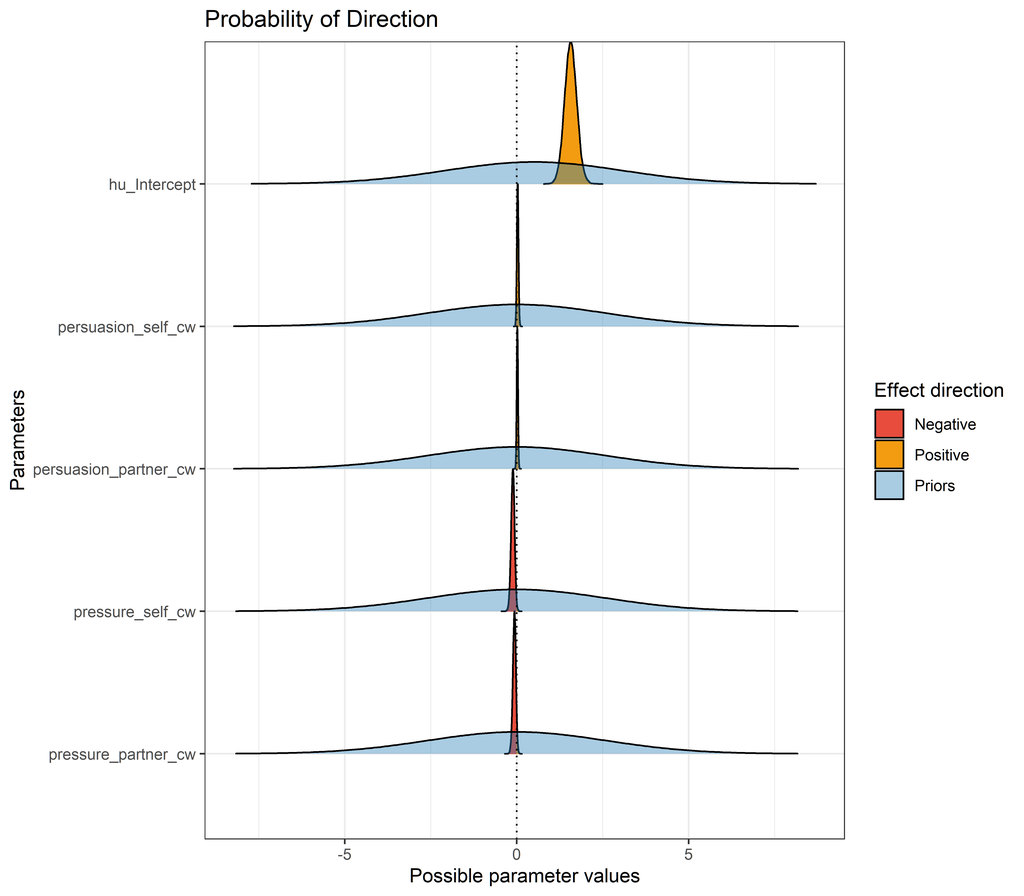

```r
# Plot continuous part of model

variable <- c(
  '(Intercept)',
  'b_persuasion_self_cw',
  'b_persuasion_partner_cw',
  'b_pressure_self_cw',
  'b_pressure_partner_cw',
  'b_pushing_self_cw',
  'b_pushing_partner_cw'
)


plot(
  bayestestR::p_direction(pa_sub, parameter = variable),
  priors = TRUE
) + theme_bw()
```

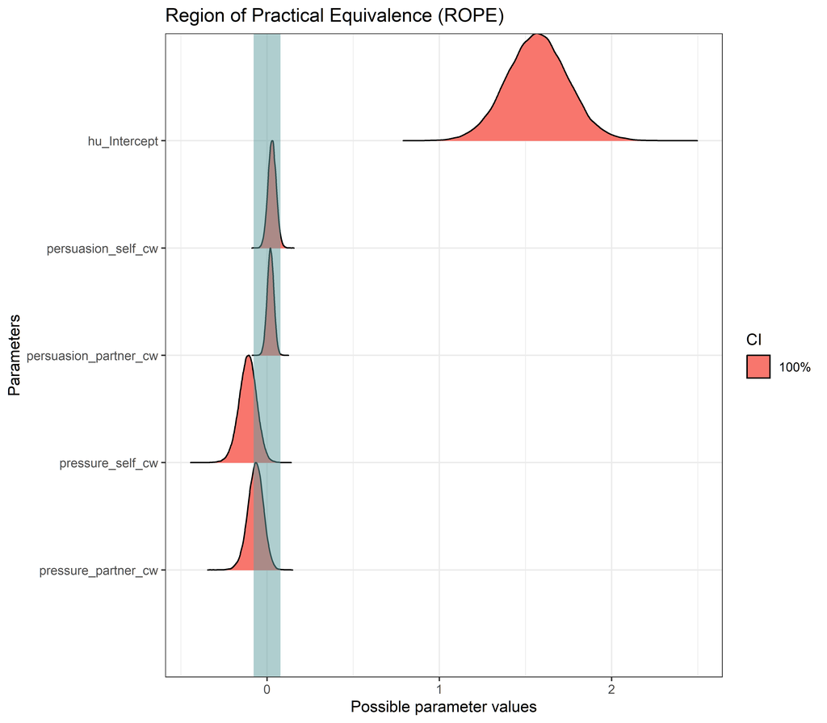

```r
plot(
  bayestestR::rope(
    pa_sub,
    parameter = variable,
    range = rope_range_continuous,
    verbose = F,
    ci = 1
  )
) + theme_bw()
```

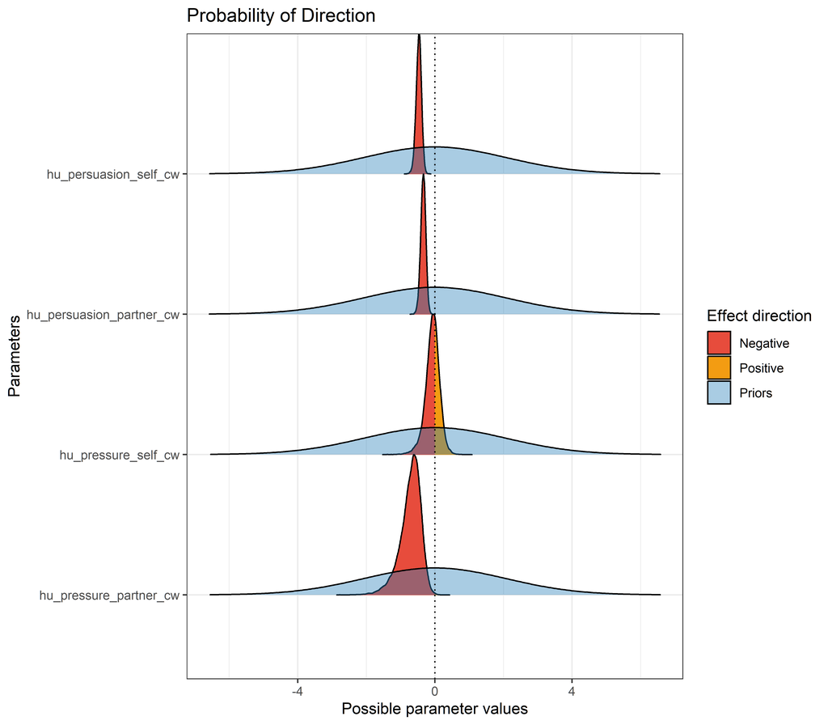

```r
# Hurdle part of the model
variable <- c(
  'b_hu_persuasion_self_cw',
  'b_hu_persuasion_partner_cw',
  'b_hu_pressure_self_cw',
  'b_hu_pressure_partner_cw',
  'b_hu_pushing_self_cw',
  'b_hu_pushing_partner_cw'
)

plot(
  bayestestR::p_direction(pa_sub, parameter = variable),
  priors = TRUE
) + theme_bw()
```

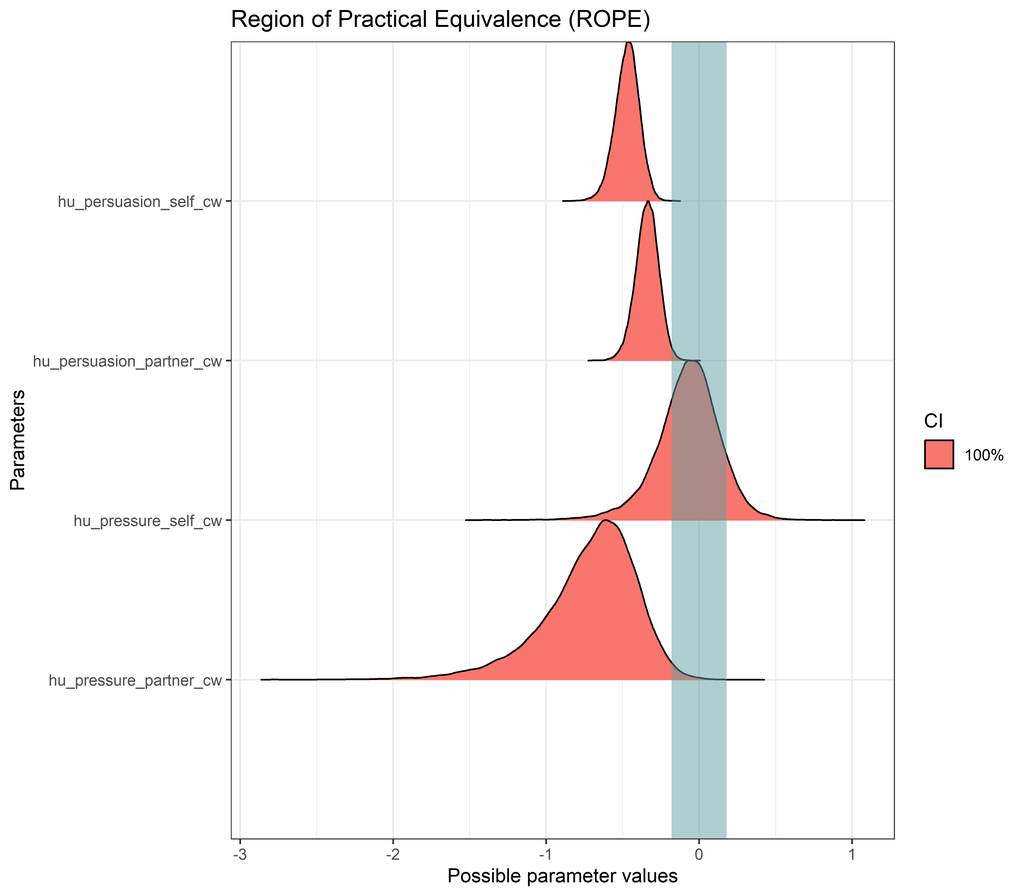

```r
# The rope range for the bernoulli part of the model is -0.18, 0.18
plot(
  bayestestR::rope(pa_sub, parameter = variable, range = c(-0.18, 0.18), ci = 1),
  verbose = FALSE
) + theme_bw()
```

## Device Based MVPA

### Lognormal Model

```r
formula <- bf(
  pa_obj ~
    persuasion_self_cw + persuasion_partner_cw +
    pressure_self_cw + pressure_partner_cw +

    persuasion_self_cb + persuasion_partner_cb +
    pressure_self_cb + pressure_partner_cb +

    plan_self + plan_partner +
    day + weartime_self_cw + weartime_self_cb +

    # Random effects
    (1 | dd | coupleID)

  + (1 + persuasion_self_cw + persuasion_partner_cw +
    pressure_self_cw + pressure_partner_cw | d_u | coupleID:userID)

  , decomp = 'QR'
  #, autocor = autocor_str
)



prior1 <- c(
  brms::set_prior("normal(0, 2.5)", class = "b")
  , brms::set_prior("normal(0, 50)", class = "Intercept")
  , brms::set_prior("normal(0, 2)", class = "sd", group = "coupleID", lb = 0)
  , brms::set_prior("student_t(3, 0, 2.5)", class = "sigma", lb = 0)
)


#brms::validate_prior(
#  prior1,
#  formula = formula,
#  data = df_double,
#  family = lognormal()
#  )

#df_minimal <- df_double[, c("AorB", all.vars(as.formula(formula)))]

pa_obj_log <- my_brm(
  mi = use_mi,
  imputed_data = implist,

  formula = formula,
  prior = prior1,
  data = df_double,
  family = lognormal(),
  #control = list(adapt_delta = 0.95),
  iter = iterations,
  warmup = warmup,
  chains = 4,
  cores = 4,
  seed = 7777,
  file = file.path("models_cache_brms", paste0("pa_obj_log_gaussian", suffix_nopushing))
)
pa_obj_log_digest <- digest::digest(pa_obj_log)
```

```r
# rope range for lognormal model
rope_factor <- sd(log(pa_obj_log$data$pa_obj))
rope_range_log = c(-0.1 * rope_factor, 0.1 * rope_factor)

summary_pa_obj <- summarize_brms(
  pa_obj_log,
  stats_to_report = stats_to_report,
  rope_range = rope_range_log,
  model_rows_fixed = model_rows_fixed,
  model_rows_random = model_rows_random,
  model_rownames_fixed = model_rownames_fixed,
  model_rownames_random = model_rownames_random,
  exponentiate = T)
summary_pa_obj %>%
  print_df(rows_to_pack = rows_to_pack)
```

|  | exp(Est.) | SE | 95% CI | pd | ROPE | inside ROPE | Rhat | Bulk_ESS | Tail_ESS |
| --- | --- | --- | --- | --- | --- | --- | --- | --- | --- |
| Intercept | 109.91*** | 5.38 | [99.85, 120.72] | 1.000 | [0.94, 1.07] | 0.000 | 1.000 | 3792 | 7771 |
| **Within-Person Effects** |  |  |  |  |  |  |  |  |  |
| Daily individual’s experienced persuasion | 1.03 | 0.01 | [ 1.00, 1.05] | 0.969 | [0.94, 1.07] | 0.998 | 1.001 | 5541 | 9672 |
| Daily partner’s experienced persuasion | 1.02 | 0.01 | [ 0.98, 1.04] | 0.848 | [0.94, 1.07] | 0.999 | 1.005 | 655 | 350 |
| Daily individual’s experienced pressure | 0.96 | 0.03 | [ 0.90, 1.02] | 0.913 | [0.94, 1.07] | 0.760 | 1.000 | 9326 | 11651 |
| Daily partner’s experienced pressure | 0.98 | 0.03 | [ 0.92, 1.05] | 0.720 | [0.94, 1.07] | 0.926 | 1.001 | 7180 | 16635 |
| Daily individual’s experienced pushing | NA | NA | NA | NA | NA | NA | NA | NA | NA |
| Daily partner’s experienced pushing | NA | NA | NA | NA | NA | NA | NA | NA | NA |
| Day | 0.97 | 0.03 | [ 0.91, 1.03] | 0.833 | [0.94, 1.07] | 0.830 | 1.001 | 8563 | 10133 |
| Own action plan | 1.07** | 0.03 | [ 1.02, 1.13] | 0.997 | [0.94, 1.07] | 0.387 | 1.001 | 2926 | 2453 |
| Partner action plan | 1.05* | 0.03 | [ 1.01, 1.10] | 0.986 | [0.94, 1.07] | 0.710 | 1.000 | 4651 | 7495 |
| Daily wear time | 1.00*** | 0.00 | [ 1.00, 1.00] | 1.000 | [0.94, 1.07] | 1.000 | 1.001 | 8113 | 7445 |
| **Between-Person Effects** |  |  |  |  |  |  |  |  |  |
| Mean individual’s experienced persuasion | 1.17 | 0.17 | [ 0.88, 1.55] | 0.860 | [0.94, 1.07] | 0.201 | 1.003 | 2552 | 4701 |
| Mean partner’s experienced persuasion | 1.06 | 0.17 | [ 0.77, 1.44] | 0.640 | [0.94, 1.07] | 0.298 | 1.004 | 2479 | 2068 |
| Mean individual’s experienced pressure | 0.79 | 0.16 | [ 0.52, 1.17] | 0.885 | [0.94, 1.07] | 0.124 | 1.002 | 3533 | 4153 |
| Mean partner’s experienced pressure | 1.10 | 0.22 | [ 0.74, 1.61] | 0.679 | [0.94, 1.07] | 0.230 | 1.004 | 2904 | 2216 |
| Mean individual’s experienced pushing | NA | NA | NA | NA | NA | NA | NA | NA | NA |
| Mean partner’s experienced pushing | NA | NA | NA | NA | NA | NA | NA | NA | NA |
| Mean wear time | 1.00 | 0.00 | [ 1.00, 1.00] | 0.617 | [0.94, 1.07] | 1.000 | 1.002 | 3578 | 3578 |
| **Random Effects (Level 3 - Couple)** |  |  |  |  |  |  |  |  |  |
| L3:sd(Intercept) | 0.18 | 0.06 | [0.03, 0.30] | NA | NA | NA | 1.008 | 504 | 227 |
| **Random Effects (Level 2 - Couple:Person)** |  |  |  |  |  |  |  |  |  |
| L2:sd(Intercept) | 0.28 | 0.04 | [0.22, 0.36] | NA | NA | NA | 1.002 | 4001 | 7979 |
| L2:sd(Daily individual’s experienced persuasion) | 0.06 | 0.01 | [0.03, 0.09] | NA | NA | NA | 1.000 | 10277 | 15952 |
| L2:sd(Daily partner’s experienced persuasion) | 0.06 | 0.02 | [0.03, 0.10] | NA | NA | NA | 1.005 | 1098 | 1790 |
| L2:sd(Daily individual’s experienced pressure) | 0.04 | 0.03 | [0.00, 0.13] | NA | NA | NA | 1.001 | 4545 | 13829 |
| L2:sd(Daily partner’s experienced pressure) | 0.04 | 0.03 | [0.00, 0.13] | NA | NA | NA | 1.000 | 4295 | 7912 |
| L2:sd(Daily individual’s experienced pushing) | NA | NA | NA | NA | NA | NA | NA | NA | NA |
| L2:sd(Daily partner’s experienced pushing) | NA | NA | NA | NA | NA | NA | NA | NA | NA |
| **Additional Parameters** |  |  |  |  |  |  |  |  |  |
| sigma | 0.55 | 0.01 | [0.53, 0.56] | NA | NA | NA | 1.002 | 1440 | 1687 |

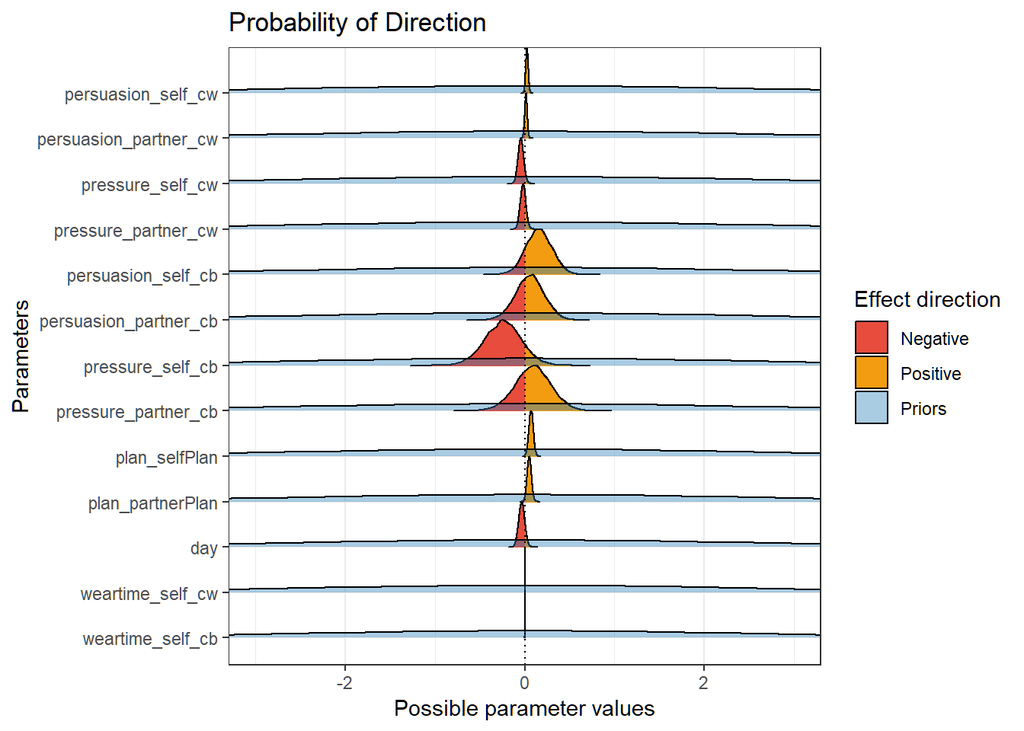

```r
plot(
  bayestestR::p_direction(pa_obj_log),
  priors = TRUE
) +
  coord_cartesian(xlim = c(-3, 3)) +
  theme_bw()
```

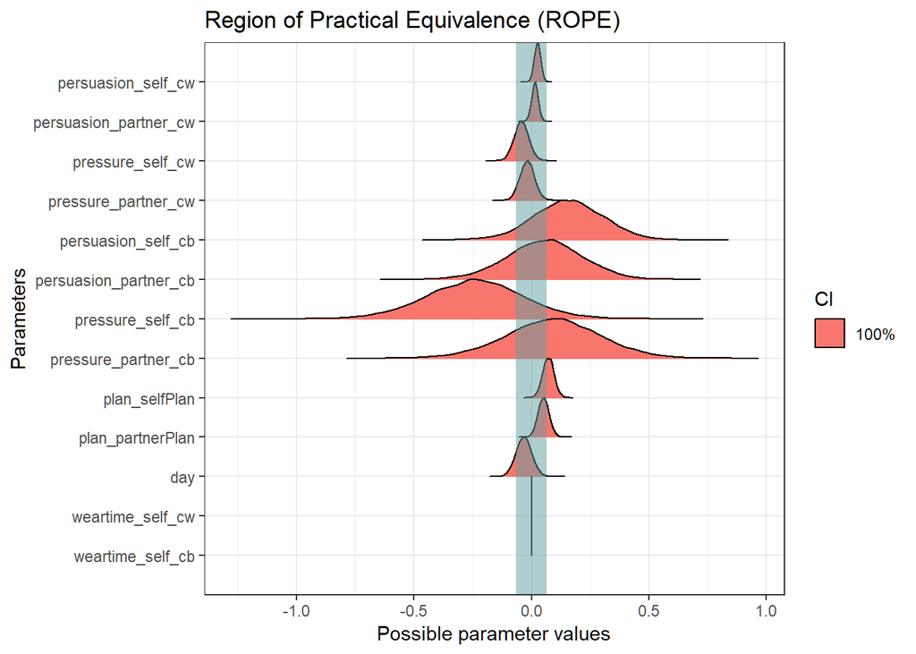

```r
plot(
  bayestestR::rope(pa_obj_log, range = rope_range_log, ci = 1)
) + theme_bw()
```

```r
# Nothing significant, no plots
```

## Affect

### Gaussian

```r
formula <- bf(
  aff ~
    persuasion_self_cw + persuasion_partner_cw +
    pressure_self_cw + pressure_partner_cw +

    persuasion_self_cb + persuasion_partner_cb +
    pressure_self_cb + pressure_partner_cb +

    plan_self + plan_partner +
    day +

    # Random effects
    (1 | dd | coupleID)

  + (1 + persuasion_self_cw + persuasion_partner_cw +
    pressure_self_cw + pressure_partner_cw | d_u | coupleID:userID)

  , decomp = 'QR'
  #, autocor = autocor_str
)


prior1 <- c(
  brms::set_prior("normal(0, 5)", class = "b")
  ,brms::set_prior("normal(0, 20)", class = "Intercept", lb=1, ub=6)
  , brms::set_prior("normal(0, 2)", class = "sd", group = "coupleID", lb = 0)
  , brms::set_prior("student_t(3, 0, 2.5)", class = "sigma", lb = 0)
)

#brms::validate_prior(
#  prior1,
#  formula = formula,
#  data = df_double,
#  family = gaussian()
#  )

#df_minimal <- df_double[, c("AorB", all.vars(as.formula(formula)))]

mood_gauss <- my_brm(
  mi = use_mi,
  imputed_data = implist,

  formula = formula,
  prior = prior1,
  data = df_double,
  family = gaussian(),
  control = list(adapt_delta = 0.95),
  iter = iterations,
  warmup = warmup,
  chains = 4,
  cores = 4,
  seed = 7777,
  file = file.path("models_cache_brms", paste0("mood_gauss", suffix_nopushing))
)
mood_gauss_digest <- digest::digest(mood_gauss)
```

```r
summary_mood <- summarize_brms(
  mood_gauss,
  stats_to_report = stats_to_report,
  model_rows_fixed = model_rows_fixed,
  model_rows_random = model_rows_random,
  model_rownames_fixed = model_rownames_fixed,
  model_rownames_random = model_rownames_random,
  exponentiate = F)

summary_mood %>%
  print_df(rows_to_pack = rows_to_pack)
```

|  | Est. | SE | 95% CI | pd | ROPE | inside ROPE | Rhat | Bulk_ESS | Tail_ESS |
| --- | --- | --- | --- | --- | --- | --- | --- | --- | --- |
| Intercept | 3.65*** | 0.10 | [ 3.45, 3.85] | 1.000 | [-0.11, 0.11] | 0.000 | 1.000 | 27860 | 27640 |
| **Within-Person Effects** |  |  |  |  |  |  |  |  |  |
| Daily individual’s experienced persuasion | 0.01 | 0.02 | [-0.03, 0.05] | 0.637 | [-0.11, 0.11] | 1.000 | 1.000 | 41123 | 32848 |
| Daily partner’s experienced persuasion | 0.02 | 0.02 | [-0.02, 0.06] | 0.880 | [-0.11, 0.11] | 1.000 | 1.000 | 49288 | 34092 |
| Daily individual’s experienced pressure | -0.02 | 0.05 | [-0.12, 0.07] | 0.696 | [-0.11, 0.11] | 0.969 | 1.000 | 55559 | 33285 |
| Daily partner’s experienced pressure | 0.03 | 0.05 | [-0.06, 0.12] | 0.749 | [-0.11, 0.11] | 0.960 | 1.000 | 55833 | 33495 |
| Daily individual’s experienced pushing | NA | NA | NA | NA | NA | NA | NA | NA | NA |
| Daily partner’s experienced pushing | NA | NA | NA | NA | NA | NA | NA | NA | NA |
| Day | 0.25*** | 0.05 | [ 0.15, 0.35] | 1.000 | [-0.11, 0.11] | 0.003 | 1.000 | 81173 | 30160 |
| Own action plan | 0.09* | 0.04 | [ 0.02, 0.16] | 0.994 | [-0.11, 0.11] | 0.756 | 1.000 | 83982 | 29816 |
| Partner action plan | 0.02 | 0.04 | [-0.05, 0.09] | 0.689 | [-0.11, 0.11] | 0.996 | 1.000 | 80776 | 28714 |
| Daily wear time | NA | NA | NA | NA | NA | NA | NA | NA | NA |
| **Between-Person Effects** |  |  |  |  |  |  |  |  |  |
| Mean individual’s experienced persuasion | 0.28 | 0.32 | [-0.36, 0.92] | 0.805 | [-0.11, 0.11] | 0.191 | 1.000 | 21007 | 25812 |
| Mean partner’s experienced persuasion | 0.36 | 0.31 | [-0.25, 0.99] | 0.877 | [-0.11, 0.11] | 0.147 | 1.000 | 23888 | 24062 |
| Mean individual’s experienced pressure | -0.13 | 0.42 | [-0.98, 0.70] | 0.617 | [-0.11, 0.11] | 0.203 | 1.000 | 24111 | 27367 |
| Mean partner’s experienced pressure | -0.36 | 0.41 | [-1.18, 0.45] | 0.813 | [-0.11, 0.11] | 0.149 | 1.000 | 27229 | 26576 |
| Mean individual’s experienced pushing | NA | NA | NA | NA | NA | NA | NA | NA | NA |
| Mean partner’s experienced pushing | NA | NA | NA | NA | NA | NA | NA | NA | NA |
| Mean wear time | NA | NA | NA | NA | NA | NA | NA | NA | NA |
| **Random Effects (Level 3 - Couple)** |  |  |  |  |  |  |  |  |  |
| L3:sd(Intercept) | 0.41 | 0.12 | [0.09, 0.64] | NA | NA | NA | 1.001 | 3623 | 2790 |
| **Random Effects (Level 2 - Couple:Person)** |  |  |  |  |  |  |  |  |  |
| L2:sd(Intercept) | 0.60 | 0.08 | [0.48, 0.78] | NA | NA | NA | 1.001 | 7274 | 13217 |
| L2:sd(Daily individual’s experienced persuasion) | 0.10 | 0.03 | [0.05, 0.15] | NA | NA | NA | 1.000 | 18324 | 20656 |
| L2:sd(Daily partner’s experienced persuasion) | 0.08 | 0.03 | [0.03, 0.14] | NA | NA | NA | 1.000 | 13283 | 13277 |
| L2:sd(Daily individual’s experienced pressure) | 0.06 | 0.05 | [0.00, 0.22] | NA | NA | NA | 1.000 | 19674 | 22937 |
| L2:sd(Daily partner’s experienced pressure) | 0.07 | 0.06 | [0.00, 0.22] | NA | NA | NA | 1.000 | 19431 | 22342 |
| L2:sd(Daily individual’s experienced pushing) | NA | NA | NA | NA | NA | NA | NA | NA | NA |
| L2:sd(Daily partner’s experienced pushing) | NA | NA | NA | NA | NA | NA | NA | NA | NA |
| **Additional Parameters** |  |  |  |  |  |  |  |  |  |
| sigma | 0.87 | 0.01 | [0.85, 0.89] | NA | NA | NA | 1.000 | 60901 | 30215 |

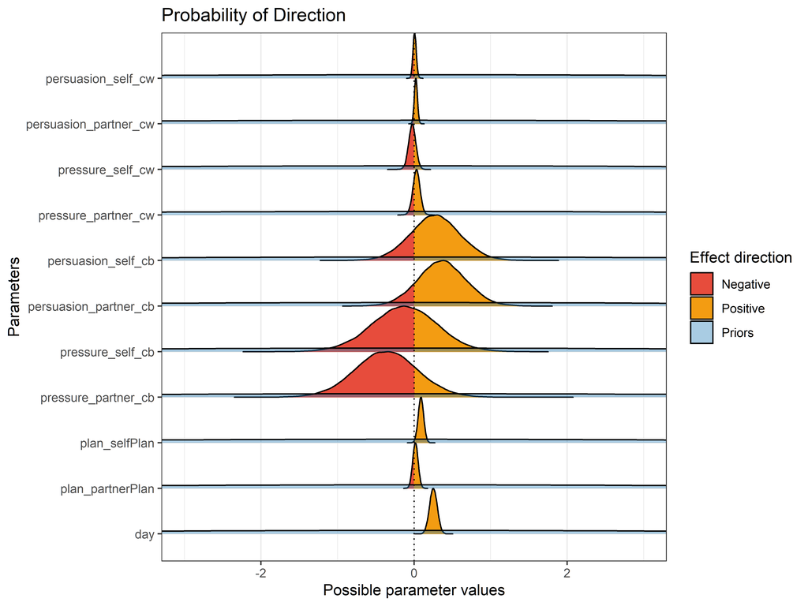

```r
plot(
  bayestestR::p_direction(mood_gauss),
  priors = TRUE
)  +
  coord_cartesian(xlim = c(-3, 3)) +
  theme_bw()
```

```
## Possible multicollinearity between b_pressure_self_cb and
##   b_persuasion_self_cb (r = 0.71). This might lead to inappropriate
##   results. See 'Details' in '?rope'.
```

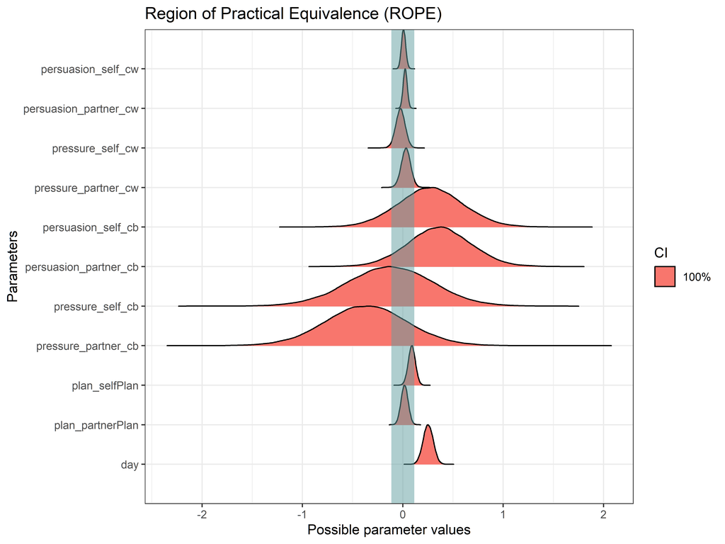

```r
plot(
  bayestestR::rope(mood_gauss, ci = 1)
) + theme_bw()
```

## Reactance

### Ordinal

```r
df_double$reactance_ordinal <- factor(df_double$reactance,
                                      levels = 0:5,
                                      ordered = TRUE)

formula <- bf(
  reactance_ordinal ~
    persuasion_self_cw + persuasion_partner_cw +
    pressure_self_cw + pressure_partner_cw +

    persuasion_self_cb + persuasion_partner_cb +
    pressure_self_cb + pressure_partner_cb +

    plan_self + plan_partner +
    day +

    # Random effects
    (1 | dd | coupleID)

  + (1 + persuasion_self_cw + persuasion_partner_cw +
    pressure_self_cw + pressure_partner_cw | d_u | coupleID:userID)

  , decomp = 'QR'
  #, autocor = autocor_str
)


prior1 <- c(
  brms::set_prior("normal(0, 2.5)", class = "b")
  , brms::set_prior("normal(0, 2)", class = "sd", group = "coupleID", lb = 0)
)


#brms::validate_prior(
#  prior1,
#  formula = formula,
#  data = df_double,
#  family = cumulative() # HURDLE_CUMULATIVE
#  )


#df_minimal <- df_double[, c("AorB", all.vars(as.formula(formula)))]

reactance_ordinal <- my_brm(
  mi = use_mi,
  imputed_data = implist,

  formula = formula,
  prior = prior1,
  data = df_double,
  family = brms::cumulative(),
  control = list(adapt_delta = 0.90),
  iter = iterations,
  warmup = warmup,
  chains = 4,
  cores = 4,
  seed = 7777
  , file = file.path("models_cache_brms", paste0("reactance_ordinal", suffix_nopushing))
)
reactance_ordinal_digest <- digest::digest(reactance_ordinal)
```

```r
summary_reactance_ordinal <- summarize_brms(
  reactance_ordinal,
  stats_to_report = stats_to_report,
  rope_range = c(-0.18, 0.18),
  model_rows_fixed = model_rows_fixed_ordinal,
  model_rows_random = model_rows_random_ordinal,
  model_rownames_fixed = model_rownames_fixed_ordinal,
  model_rownames_random = model_rownames_random_ordinal,
  exponentiate = T)
```

# Check for Multicollinearity

Low Correlation

```
              Term  VIF     VIF 95% CI Increased SE Tolerance
  pressure_self_cw 4.72 [ 4.49,  4.97]         2.17      0.21
```

pressure_partner_cw 1.56 [ 1.50, 1.63] 1.25 0.64 persuasion_self_cb 1.28 [ 1.23, 1.32] 1.13 0.78 persuasion_partner_cb 1.08 [ 1.06, 1.13] 1.04 0.92 pressure_self_cb 1.07 [ 1.05, 1.11] 1.04 0.93 pressure_partner_cb 1.06 [ 1.04, 1.10] 1.03 0.94 Tolerance 95% CI [0.20, 0.22] [0.61, 0.67] [0.75, 0.81] [0.89, 0.95] [0.90, 0.96] [0.91, 0.97]

Moderate Correlation

```
           Term  VIF     VIF 95% CI Increased SE Tolerance Tolerance 95% CI
```

persuasion_self_cw 9.03 [ 8.55, 9.54] 3.01 0.11 [0.10, 0.12] plan_self 5.78 [ 5.48, 6.09] 2.40 0.17 [0.16, 0.18] plan_partner 6.41 [ 6.08, 6.77] 2.53 0.16 [0.15, 0.16] day 8.15 [ 7.72, 8.61] 2.86 0.12 [0.12, 0.13]

High Correlation

```
              Term   VIF     VIF 95% CI Increased SE Tolerance
```

persuasion_partner_cw 11.03 [10.44, 11.66] 3.32 0.09 Tolerance 95% CI [0.09, 0.10]

```r
summary_reactance_ordinal %>%
  print_df(rows_to_pack = rows_to_pack_ordinal)
```

|  | OR | SE | 95% CI | pd | ROPE | inside ROPE | Rhat | Bulk_ESS | Tail_ESS |
| --- | --- | --- | --- | --- | --- | --- | --- | --- | --- |
| Intercept | NA | NA | NA | NA | NA | NA | NA | NA | NA |
| Intercept[1] | 3.53*** | 1.12 | [ 1.94, 6.78] | 1.000 | [0.84, 1.20] | 0.000 | 1.000 | 52358 | 33328 |
| Intercept[2] | 7.84*** | 2.56 | [ 4.22, 15.35] | 1.000 | [0.84, 1.20] | 0.000 | 1.000 | 51187 | 33069 |
| Intercept[3] | 21.26*** | 7.46 | [ 10.99, 43.44] | 1.000 | [0.84, 1.20] | 0.000 | 1.000 | 51237 | 32637 |
| Intercept[4] | 90.65*** | 36.26 | [ 42.39, 205.82] | 1.000 | [0.84, 1.20] | 0.000 | 1.000 | 53462 | 31271 |
| Intercept[5] | 2625.05*** | 1750.11 | [779.98, 10918.90] | 1.000 | [0.84, 1.20] | 0.000 | 1.001 | 70968 | 30325 |
| **Within-Person Effects** |  |  |  |  |  |  |  |  |  |
| Daily individual’s experienced persuasion | 0.82* | 0.08 | [ 0.66, 0.98] | 0.985 | [0.84, 1.20] | 0.414 | 1.000 | 35016 | 30735 |
| Daily partner’s experienced persuasion | 1.00 | 0.09 | [ 0.81, 1.19] | 0.514 | [0.84, 1.20] | 0.937 | 1.000 | 52400 | 31633 |
| Daily individual’s experienced pressure | 2.04*** | 0.31 | [ 1.47, 2.78] | 1.000 | [0.84, 1.20] | 0.002 | 1.000 | 48840 | 30418 |
| Daily partner’s experienced pressure | 1.14 | 0.23 | [ 0.70, 1.69] | 0.735 | [0.84, 1.20] | 0.516 | 1.000 | 45496 | 27122 |
| Daily individual’s experienced pushing | NA | NA | NA | NA | NA | NA | NA | NA | NA |
| Daily partner’s experienced pushing | NA | NA | NA | NA | NA | NA | NA | NA | NA |
| Day | 1.54 | 0.56 | [ 0.76, 3.12] | 0.883 | [0.84, 1.20] | 0.198 | 1.000 | 81898 | 31489 |
| Own action plan | 1.07 | 0.27 | [ 0.65, 1.77] | 0.601 | [0.84, 1.20] | 0.508 | 1.000 | 85655 | 31317 |
| Partner action plan | 0.85 | 0.20 | [ 0.53, 1.37] | 0.750 | [0.84, 1.20] | 0.449 | 1.000 | 88195 | 30315 |
| Daily wear time | NA | NA | NA | NA | NA | NA | NA | NA | NA |
| **Between-Person Effects** |  |  |  |  |  |  |  |  |  |
| Mean individual’s experienced persuasion | 0.93 | 0.63 | [ 0.24, 3.84] | 0.547 | [0.84, 1.20] | 0.210 | 1.000 | 32692 | 29225 |
| Mean partner’s experienced persuasion | 0.76 | 0.51 | [ 0.20, 2.99] | 0.658 | [0.84, 1.20] | 0.192 | 1.000 | 39593 | 30913 |
| Mean individual’s experienced pressure | 5.50* | 4.48 | [ 1.15, 31.92] | 0.983 | [0.84, 1.20] | 0.018 | 1.000 | 41957 | 29760 |
| Mean partner’s experienced pressure | 0.90 | 0.74 | [ 0.15, 4.31] | 0.549 | [0.84, 1.20] | 0.174 | 1.000 | 39305 | 29607 |
| Mean individual’s experienced pushing | NA | NA | NA | NA | NA | NA | NA | NA | NA |
| Mean partner’s experienced pushing | NA | NA | NA | NA | NA | NA | NA | NA | NA |
| Mean wear time | NA | NA | NA | NA | NA | NA | NA | NA | NA |
| **Random Effects (Level 3 - Couple)** |  |  |  |  |  |  |  |  |  |
| L3:sd(Intercept) | 0.48 | 0.31 | [0.03, 1.05] | NA | NA | NA | 1.001 | 7836 | 17877 |
| **Random Effects (Level 2 - Couple:Person)** |  |  |  |  |  |  |  |  |  |
| L2:sd(Intercept) | 0.93 | 0.31 | [0.24, 1.57] | NA | NA | NA | 1.001 | 7171 | 7306 |
| L2:sd(Daily individual’s experienced persuasion) | 0.34 | 0.14 | [0.05, 0.62] | NA | NA | NA | 1.000 | 8470 | 9905 |
| L2:sd(Daily partner’s experienced persuasion) | 0.20 | 0.14 | [0.01, 0.50] | NA | NA | NA | 1.000 | 15128 | 21088 |
| L2:sd(Daily individual’s experienced pressure) | 0.37 | 0.24 | [0.02, 0.92] | NA | NA | NA | 1.000 | 12105 | 19252 |
| L2:sd(Daily partner’s experienced pressure) | 0.25 | 0.24 | [0.01, 1.15] | NA | NA | NA | 1.000 | 17913 | 25165 |
| L2:sd(Daily individual’s experienced pushing) | NA | NA | NA | NA | NA | NA | NA | NA | NA |
| L2:sd(Daily partner’s experienced pushing) | NA | NA | NA | NA | NA | NA | NA | NA | NA |
| **Additional Parameters** |  |  |  |  |  |  |  |  |  |
| sigma | NA | NA | NA | NA | NA | NA | NA | NA | NA |
| disc | 1.00 | 0.00 | [1.00, 1.00] | NA | NA | NA | NA | NA | NA |

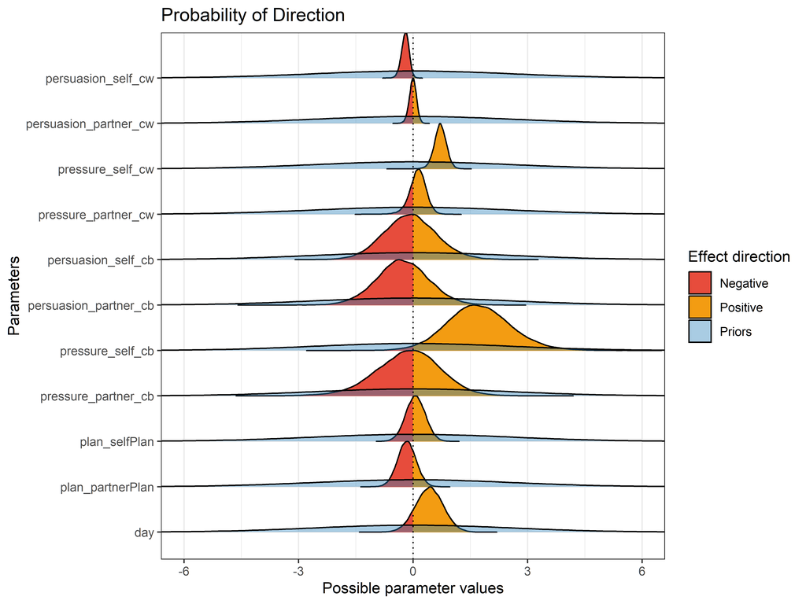

```r
plot(
  bayestestR::p_direction(reactance_ordinal),
  priors = TRUE
) +
  coord_cartesian(xlim = c(-6, 6)) +
  theme_bw()
```

```
## Possible multicollinearity between b_Intercept[4] and b_Intercept[2] (r
##   = 0.82), b_Intercept[4] and b_Intercept[3] (r = 0.87). This might lead
##   to inappropriate results. See 'Details' in '?rope'.
```

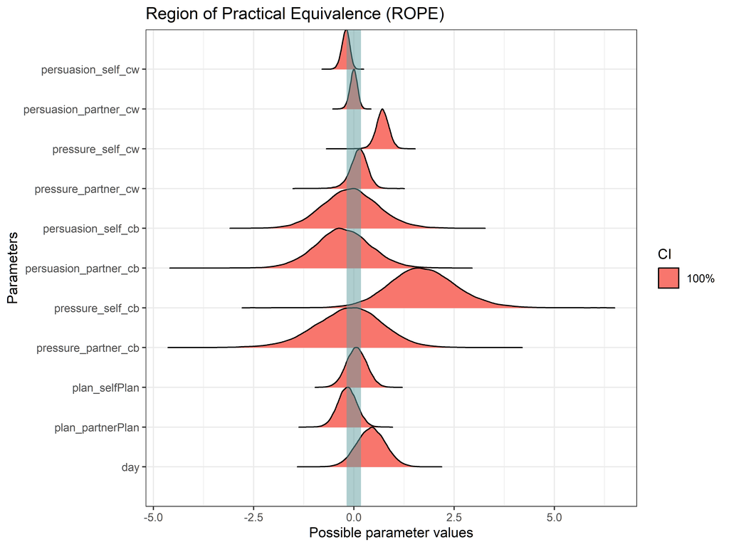

```r
plot(
  bayestestR::rope(reactance_ordinal, range = c(-0.18, 0.18), ci = 1)
) + theme_bw()
```

### Binary

```r
introduce_binary_reactance <- function(data) {
  data$is_reactance <- factor(data$reactance > 0, levels = c(FALSE, TRUE), labels = c(0, 1))
  return(data)
}



df_double <- introduce_binary_reactance(df_double)
if (use_mi) {
  for (i in seq_along(implist)) {
    implist[[i]] <- introduce_binary_reactance(implist[[i]])
  }
}


formula <- bf(
  is_reactance ~
    persuasion_self_cw + persuasion_partner_cw +
    pressure_self_cw + pressure_partner_cw +

    persuasion_self_cb + persuasion_partner_cb +
    pressure_self_cb + pressure_partner_cb +

    plan_self + plan_partner +
    day +

    # Random effects
    (1 | dd | coupleID)

  + (1 + persuasion_self_cw + persuasion_partner_cw +
    pressure_self_cw + pressure_partner_cw | d_u | coupleID:userID)

  , decomp = 'QR'
  #, autocor = autocor_str
  )



prior1 <- c(
  brms::set_prior("normal(0, 2.5)", class = "b")
  , brms::set_prior("normal(0, 10)", class = "Intercept", lb=0, ub=5)
  , brms::set_prior("normal(0, 2)", class = "sd", group = "coupleID", lb = 0)
)


#brms::validate_prior(
#  prior1,
#  formula = formula,
#  data = df_double,
#  family = bernoulli()
#  )



#df_minimal <- df_double[, c("AorB", all.vars(as.formula(formula)))]

is_reactance <- my_brm(
  mi = use_mi,
  imputed_data = implist,

  formula = formula,
  prior = prior1,
  data = df_double,
  family = brms::bernoulli(),
  control = list(adapt_delta = 0.95),
  iter = iterations,
  warmup = warmup,
  chains = 4,
  cores = 4,
  seed = 7777,
  file = file.path("models_cache_brms", paste0("is_reactance", suffix_nopushing))
  #, file_refit = 'always'
)
is_reactance_digest <- digest::digest(is_reactance)
```

```r
summary_is_reactance <- summarize_brms(
  is_reactance,
  stats_to_report = stats_to_report,
  model_rows_fixed = model_rows_fixed,
  model_rows_random = model_rows_random,
  model_rownames_fixed = model_rownames_fixed,
  model_rownames_random = model_rownames_random,
  exponentiate = T)

summary_is_reactance %>%
  print_df(rows_to_pack = rows_to_pack)
```

|  | OR | SE | 95% CI | pd | ROPE | inside ROPE | Rhat | Bulk_ESS | Tail_ESS |
| --- | --- | --- | --- | --- | --- | --- | --- | --- | --- |
| Intercept | 0.31*** | 0.11 | [0.15, 0.61] | 1.000 | [0.83, 1.20] | 0.003 | 1.000 | 26449 | 30943 |
| **Within-Person Effects** |  |  |  |  |  |  |  |  |  |
| Daily individual’s experienced persuasion | 0.83 | 0.09 | [0.66, 1.01] | 0.965 | [0.83, 1.20] | 0.500 | 1.000 | 21224 | 28463 |
| Daily partner’s experienced persuasion | 1.04 | 0.14 | [0.79, 1.36] | 0.623 | [0.83, 1.20] | 0.804 | 1.000 | 25993 | 27174 |
| Daily individual’s experienced pressure | 2.90** | 1.12 | [1.53, 7.97] | 0.999 | [0.83, 1.20] | 0.004 | 1.000 | 14063 | 18434 |
| Daily partner’s experienced pressure | 1.21 | 0.48 | [0.45, 3.29] | 0.689 | [0.83, 1.20] | 0.308 | 1.000 | 19925 | 19453 |
| Daily individual’s experienced pushing | NA | NA | NA | NA | NA | NA | NA | NA | NA |
| Daily partner’s experienced pushing | NA | NA | NA | NA | NA | NA | NA | NA | NA |
| Day | 1.76 | 0.71 | [0.80, 3.92] | 0.920 | [0.83, 1.20] | 0.136 | 1.000 | 47711 | 32094 |
| Own action plan | 1.21 | 0.39 | [0.65, 2.32] | 0.725 | [0.83, 1.20] | 0.367 | 1.000 | 43177 | 30516 |
| Partner action plan | 0.79 | 0.24 | [0.43, 1.44] | 0.781 | [0.83, 1.20] | 0.342 | 1.000 | 44191 | 29372 |
| Daily wear time | NA | NA | NA | NA | NA | NA | NA | NA | NA |
| **Between-Person Effects** |  |  |  |  |  |  |  |  |  |
| Mean individual’s experienced persuasion | 1.95 | 1.66 | [0.39, 11.47] | 0.787 | [0.83, 1.20] | 0.125 | 1.000 | 11677 | 21471 |
| Mean partner’s experienced persuasion | 0.80 | 0.68 | [0.15, 4.58] | 0.599 | [0.83, 1.20] | 0.164 | 1.000 | 19773 | 27847 |
| Mean individual’s experienced pressure | 34.75** | 45.25 | [3.02, 597.80] | 0.998 | [0.83, 1.20] | 0.002 | 1.000 | 16272 | 22596 |
| Mean partner’s experienced pressure | 1.20 | 1.63 | [0.07, 15.76] | 0.553 | [0.83, 1.20] | 0.105 | 1.000 | 15909 | 23378 |
| Mean individual’s experienced pushing | NA | NA | NA | NA | NA | NA | NA | NA | NA |
| Mean partner’s experienced pushing | NA | NA | NA | NA | NA | NA | NA | NA | NA |
| Mean wear time | NA | NA | NA | NA | NA | NA | NA | NA | NA |
| **Random Effects (Level 3 - Couple)** |  |  |  |  |  |  |  |  |  |
| L3:sd(Intercept) | 0.78 | 0.41 | [0.06, 1.53] | NA | NA | NA | 1.001 | 3361 | 6963 |
| **Random Effects (Level 2 - Couple:Person)** |  |  |  |  |  |  |  |  |  |
| L2:sd(Intercept) | 1.22 | 0.39 | [0.39, 2.00] | NA | NA | NA | 1.001 | 3521 | 4306 |
| L2:sd(Daily individual’s experienced persuasion) | 0.31 | 0.17 | [0.02, 0.65] | NA | NA | NA | 1.001 | 5274 | 7860 |
| L2:sd(Daily partner’s experienced persuasion) | 0.50 | 0.21 | [0.12, 0.98] | NA | NA | NA | 1.000 | 8432 | 7475 |
| L2:sd(Daily individual’s experienced pressure) | 1.25 | 0.64 | [0.22, 2.89] | NA | NA | NA | 1.001 | 7574 | 7054 |
| L2:sd(Daily partner’s experienced pressure) | 0.80 | 0.73 | [0.04, 3.19] | NA | NA | NA | 1.000 | 9480 | 16567 |
| L2:sd(Daily individual’s experienced pushing) | NA | NA | NA | NA | NA | NA | NA | NA | NA |
| L2:sd(Daily partner’s experienced pushing) | NA | NA | NA | NA | NA | NA | NA | NA | NA |
| **Additional Parameters** |  |  |  |  |  |  |  |  |  |
| sigma | NA | NA | NA | NA | NA | NA | NA | NA | NA |

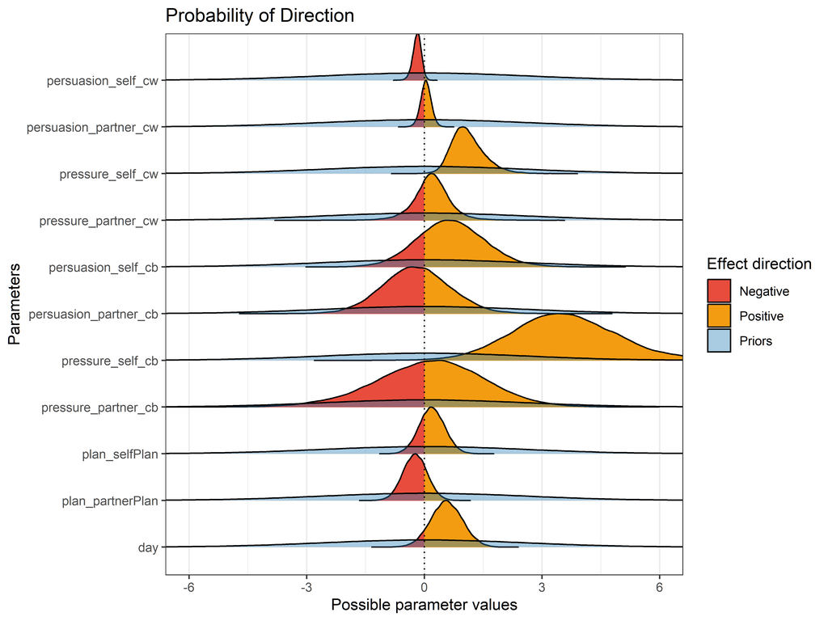

```r
plot(
  bayestestR::p_direction(is_reactance),
  priors = TRUE
) +
  coord_cartesian(xlim = c(-6, 6)) +
  theme_bw()
```

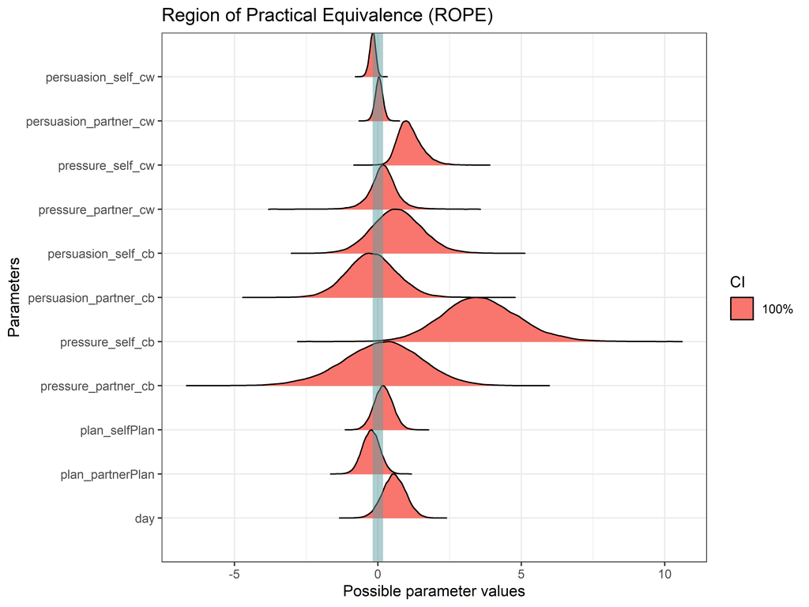

```r
plot(
  bayestestR::rope(is_reactance, ci = 1)
) + theme_bw()
```

# Report All Models

```r
summary_all_models <- report_side_by_side(
  pa_sub,
  pa_obj_log,
  mood_gauss,
  is_reactance,

  stats_to_report = c('CI'),
  model_rows_random = model_rows_random,
  model_rows_fixed = model_rows_fixed,
  model_rownames_random = model_rownames_random,
  model_rownames_fixed = model_rownames_fixed
)
```

[1] “pa_sub”

[1] “pa_obj_log”

[1] “mood_gauss” [1] “is_reactance”

```r
summary_all_models <- summary_all_models %>%
  print_df(rows_to_pack = rows_to_pack) %>%
  add_header_above(
    c(
      " ", "Hurdle Component" = 2, "Non-Zero Component" = 2,
      " " = 6
    )
  ) %>%
  add_header_above(
    c(" ", "Subjective MVPA Hurdle Lognormal" = 4,
      "Device-Based MVPA Log (Gaussian)" = 2,
      "Mood Gaussian" = 2,
      #"Reactance Ordinal" = 2,
      "Reactance Dichotome" = 2
    )
  )

export_xlsx(
  summary_all_models,
  rows_to_pack = rows_to_pack,
  file.path("Output", paste0("AllModels", suffix_nopushing, ".xlsx")),
  merge_option = 'header',
  simplify_2nd_row = TRUE,
  line_above_rows = c(1,2),
  line_below_rows = c(-1)
)
summary_all_models
```

|  | Subjective MVPA Hurdle Lognormal Hurdle Component exp(Est.)_hu pa_sub | Subjective MVPA Hurdle Lognormal Hurdle Component 95% CI_hu pa_sub | Subjective MVPA Hurdle Lognormal Non-Zero Component exp(Est.)_nonzero pa_sub | Subjective MVPA Hurdle Lognormal Non-Zero Component 95% CI_nonzero pa_sub | Device-Based MVPA Log (Gaussian) exp(Est.) pa_obj_log | Device-Based MVPA Log (Gaussian) 95% CI pa_obj_log | Mood Gaussian Est. mood_gauss | Mood Gaussian 95% CI mood_gauss | Reactance Dichotome OR is_reactance | Reactance Dichotome 95% CI is_reactance |
| --- | --- | --- | --- | --- | --- | --- | --- | --- | --- | --- |
| Intercept | 0.21*** | [ 0.15, 0.29] | 37.02*** | [31.30, 43.69] | 109.91*** | [99.85, 120.72] | 3.65*** | [ 3.45, 3.85] | 0.31*** | [0.15, 0.61] |
| **Within-Person Effects** |  |  |  |  |  |  |  |  |  |  |
| Daily individual’s experienced persuasion | 1.60*** | [ 1.38, 1.89] | 1.03 | [ 0.98, 1.08] | 1.03 | [ 1.00, 1.05] | 0.01 | [-0.03, 0.05] | 0.83 | [0.66, 1.01] |
| Daily partner’s experienced persuasion | 1.40*** | [ 1.22, 1.64] | 1.02 | [ 0.98, 1.06] | 1.02 | [ 0.98, 1.04] | 0.02 | [-0.02, 0.06] | 1.04 | [0.79, 1.36] |
| Daily individual’s experienced pressure | 1.06 | [ 0.74, 1.72] | 0.89* | [ 0.80, 0.99] | 0.96 | [ 0.90, 1.02] | -0.02 | [-0.12, 0.07] | 2.90** | [1.53, 7.97] |
| Daily partner’s experienced pressure | 1.96** | [ 1.27, 4.37] | 0.94 | [ 0.85, 1.02] | 0.98 | [ 0.92, 1.05] | 0.03 | [-0.06, 0.12] | 1.21 | [0.45, 3.29] |
| Daily individual’s experienced pushing | NA | NA | NA | NA | NA | NA | NA | NA | NA | NA |
| Daily partner’s experienced pushing | NA | NA | NA | NA | NA | NA | NA | NA | NA | NA |
| Day | 0.78 | [ 0.58, 1.05] | 0.95 | [ 0.85, 1.07] | 0.97 | [ 0.91, 1.03] | 0.25*** | [ 0.15, 0.35] | 1.76 | [0.80, 3.92] |
| Own action plan | 10.71*** | [ 8.73, 13.21] | 1.36*** | [ 1.23, 1.49] | 1.07** | [ 1.02, 1.13] | 0.09* | [ 0.02, 0.16] | 1.21 | [0.65, 2.32] |
| Partner action plan | 1.27* | [ 1.04, 1.56] | 1.06 | [ 0.97, 1.15] | 1.05* | [ 1.01, 1.10] | 0.02 | [-0.05, 0.09] | 0.79 | [0.43, 1.44] |
| Daily wear time | NA | NA | NA | NA | 1.00*** | [ 1.00, 1.00] | NA | NA | NA | NA |
| **Between-Person Effects** |  |  |  |  |  |  |  |  |  |  |
| Mean individual’s experienced persuasion | 1.79 | [ 0.83, 3.82] | 1.14 | [ 0.81, 1.61] | 1.17 | [ 0.88, 1.55] | 0.28 | [-0.36, 0.92] | 1.95 | [0.39, 11.47] |
| Mean partner’s experienced persuasion | 1.88 | [ 0.87, 3.99] | 0.99 | [ 0.70, 1.40] | 1.06 | [ 0.77, 1.44] | 0.36 | [-0.25, 0.99] | 0.80 | [0.15, 4.58] |
| Mean individual’s experienced pressure | 0.14*** | [ 0.04, 0.41] | 0.93 | [ 0.43, 1.98] | 0.79 | [ 0.52, 1.17] | -0.13 | [-0.98, 0.70] | 34.75** | [3.02, 597.80] |
| Mean partner’s experienced pressure | 0.28* | [ 0.08, 0.83] | 0.87 | [ 0.41, 1.84] | 1.10 | [ 0.74, 1.61] | -0.36 | [-1.18, 0.45] | 1.20 | [0.07, 15.76] |
| Mean individual’s experienced pushing | NA | NA | NA | NA | NA | NA | NA | NA | NA | NA |
| Mean partner’s experienced pushing | NA | NA | NA | NA | NA | NA | NA | NA | NA | NA |
| Mean wear time | NA | NA | NA | NA | 1.00 | [ 1.00, 1.00] | NA | NA | NA | NA |
| **Random Effects (Level 3 - Couple)** |  |  |  |  |  |  |  |  |  |  |
| L3:sd(Intercept) | 0.76 | [0.54, 1.05] | 0.29 | [0.15, 0.42] | 0.18 | [0.03, 0.30] | 0.41 | [0.09, 0.64] | 0.78 | [0.06, 1.53] |
| **Random Effects (Level 2 - Couple:Person)** |  |  |  |  |  |  |  |  |  |  |
| L2:sd(Intercept) | 0.39 | [0.20, 0.62] | 0.23 | [0.16, 0.33] | 0.28 | [0.22, 0.36] | 0.60 | [0.48, 0.78] | 1.22 | [0.39, 2.00] |
| L2:sd(Daily individual’s experienced persuasion) | 0.35 | [0.15, 0.56] | 0.13 | [0.09, 0.17] | 0.06 | [0.03, 0.09] | 0.10 | [0.05, 0.15] | 0.31 | [0.02, 0.65] |
| L2:sd(Daily partner’s experienced persuasion) | 0.35 | [0.16, 0.56] | 0.07 | [0.02, 0.12] | 0.06 | [0.03, 0.10] | 0.08 | [0.03, 0.14] | 0.50 | [0.12, 0.98] |
| L2:sd(Daily individual’s experienced pressure) | 0.44 | [0.02, 1.43] | 0.08 | [0.00, 0.23] | 0.04 | [0.00, 0.13] | 0.06 | [0.00, 0.22] | 1.25 | [0.22, 2.89] |
| L2:sd(Daily partner’s experienced pressure) | 0.54 | [0.03, 1.78] | 0.07 | [0.00, 0.19] | 0.04 | [0.00, 0.13] | 0.07 | [0.00, 0.22] | 0.80 | [0.04, 3.19] |
| L2:sd(Daily individual’s experienced pushing) | NA | NA | NA | NA | NA | NA | NA | NA | NA | NA |
| L2:sd(Daily partner’s experienced pushing) | NA | NA | NA | NA | NA | NA | NA | NA | NA | NA |
| **Additional Parameters** |  |  |  |  |  |  |  |  |  |  |
| sigma | NA | NA | 0.66 | [0.64, 0.69] | 0.55 | [0.53, 0.56] | 0.87 | [0.85, 0.89] | NA | NA |

# ONLY PUSHING

### Hurdle Lognormal Model

```r
formula <- bf(
  pa_sub ~
    pushing_self_cw + pushing_partner_cw +
    pushing_self_cb + pushing_partner_cb +

    #plan_self + plan_partner +
    day +

    # Random effects
    (1 | dd | coupleID)

  + (1 + pushing_self_cw + pushing_partner_cw | d_u | coupleID:userID),

  hu = ~ pushing_self_cw + pushing_partner_cw +
    pushing_self_cb + pushing_partner_cb +

    #plan_self + plan_partner +
    day +

    # Random effects
    (1 | dd | coupleID)

  + (1 + pushing_self_cw + pushing_partner_cw | d_u | coupleID:userID)

  , decomp = 'QR'
  #, autocor = autocor_str
)

prior1 <- c(
  brms::set_prior("normal(0, 2.5)", class = "b")
  , brms::set_prior("normal(0, 2)", class = "b", dpar = "hu")
  , brms::set_prior("normal(0, 50)", class = "Intercept") # for non-zero PA
  , brms::set_prior("normal(0.5, 2.5)", class = "Intercept", dpar = 'hu') # hurdle part
  , brms::set_prior("normal(0, 2)", class = "sd", group = "coupleID", lb = 0)
  , brms::set_prior("student_t(3, 0, 2.5)", class = "sigma", lb = 0)
)

#brms::validate_prior(
#  prior1,
#  formula = formula,
#  data = df_double,
#  family = hurdle_lognormal()
#)

#df_minimal <- df_double[, c("AorB", all.vars(as.formula(formula)))]

pa_sub <- my_brm(
  mi = use_mi,
  imputed_data = implist,

  formula = formula,
  prior = prior1,
  data = df_double,
  family = brms::hurdle_lognormal(),
  #family = brms::hurdle_negbinomial(),
  #family = brms::hurdle_poisson(),
  control = list(adapt_delta = 0.90),
  iter = iterations,
  warmup = warmup,
  chains = 4,
  cores = 4,
  seed = 42,
  file = file.path("models_cache_brms", paste0("pa_sub_hu_lognormal", suffix_onlypushing))
  #, file_refit = 'always'
)
pa_sub_digest <- digest::digest(pa_sub)
```

```r
# rope range for continuous part of the model
rope_factor <- sd(log(pa_sub$data$pa_sub[pa_sub$data$pa_sub > 0]))
rope_range_continuous = c(-0.1 * rope_factor, 0.1 * rope_factor)

summary_pa_sub <- summarize_brms(
  pa_sub,
  stats_to_report = stats_to_report,
  rope_range = rope_range_continuous,
  hu_rope_range = c(-0.18, 0.18),
  model_rows_fixed = model_rows_fixed,
  model_rows_random = model_rows_random,
  model_rownames_fixed = model_rownames_fixed,
  model_rownames_random = model_rownames_random,
  exponentiate = T)
# Print the updated dataframe
summary_pa_sub %>%
  print_df(rows_to_pack = rows_to_pack)
```

|  | exp(Est.)_hu | SE_hu | 95% CI_hu | pd_hu | ROPE_hu | inside ROPE_hu | Rhat_hu | Bulk_ESS_hu | Tail_ESS_hu | exp(Est.)_nonzero | SE_nonzero | 95% CI_nonzero | pd_nonzero | ROPE_nonzero | inside ROPE_nonzero | Rhat_nonzero | Bulk_ESS_nonzero | Tail_ESS_nonzero |
| --- | --- | --- | --- | --- | --- | --- | --- | --- | --- | --- | --- | --- | --- | --- | --- | --- | --- | --- |
| Intercept | 3.93*** | 1.05 | [ 2.32, 6.72] | 1.000 | [0.84, 1.20] | 0.000 | 1.000 | 14247 | 21810 | 56.49*** | 4.36 | [48.38, 65.73] | 1.000 | [0.93, 1.08] | 0.000 | 1.000 | 12212 | 19884 |
| **Within-Person Effects** |  |  |  |  |  |  |  |  |  |  |  |  |  |  |  |  |  |  |
| Daily individual’s experienced persuasion | NA | NA | NA | NA | NA | NA | NA | NA | NA | NA | NA | NA | NA | NA | NA | NA | NA | NA |
| Daily partner’s experienced persuasion | NA | NA | NA | NA | NA | NA | NA | NA | NA | NA | NA | NA | NA | NA | NA | NA | NA | NA |
| Daily individual’s experienced pressure | NA | NA | NA | NA | NA | NA | NA | NA | NA | NA | NA | NA | NA | NA | NA | NA | NA | NA |
| Daily partner’s experienced pressure | NA | NA | NA | NA | NA | NA | NA | NA | NA | NA | NA | NA | NA | NA | NA | NA | NA | NA |
| Daily individual’s experienced pushing | 1.59** | 0.23 | [ 1.23, 2.28] | 0.999 | [0.84, 1.20] | 0.016 | 1.000 | 28484 | 22555 | 0.97 | 0.03 | [ 0.92, 1.03] | 0.825 | [0.93, 1.08] | 0.967 | 1.000 | 41770 | 29914 |
| Daily partner’s experienced pushing | 1.92*** | 0.35 | [ 1.42, 3.09] | 1.000 | [0.84, 1.20] | 0.001 | 1.000 | 19768 | 20074 | 0.98 | 0.03 | [ 0.93, 1.04] | 0.756 | [0.93, 1.08] | 0.981 | 1.000 | 43735 | 29038 |
| Day | 0.59* | 0.15 | [ 0.36, 0.97] | 0.980 | [0.84, 1.20] | 0.088 | 1.000 | 60382 | 31296 | 0.91 | 0.07 | [ 0.78, 1.05] | 0.906 | [0.93, 1.08] | 0.376 | 1.000 | 56116 | 30706 |
| Own action plan | NA | NA | NA | NA | NA | NA | NA | NA | NA | NA | NA | NA | NA | NA | NA | NA | NA | NA |
| Partner action plan | NA | NA | NA | NA | NA | NA | NA | NA | NA | NA | NA | NA | NA | NA | NA | NA | NA | NA |
| Daily wear time | NA | NA | NA | NA | NA | NA | NA | NA | NA | NA | NA | NA | NA | NA | NA | NA | NA | NA |
| **Between-Person Effects** |  |  |  |  |  |  |  |  |  |  |  |  |  |  |  |  |  |  |
| Mean individual’s experienced persuasion | NA | NA | NA | NA | NA | NA | NA | NA | NA | NA | NA | NA | NA | NA | NA | NA | NA | NA |
| Mean partner’s experienced persuasion | NA | NA | NA | NA | NA | NA | NA | NA | NA | NA | NA | NA | NA | NA | NA | NA | NA | NA |
| Mean individual’s experienced pressure | NA | NA | NA | NA | NA | NA | NA | NA | NA | NA | NA | NA | NA | NA | NA | NA | NA | NA |
| Mean partner’s experienced pressure | NA | NA | NA | NA | NA | NA | NA | NA | NA | NA | NA | NA | NA | NA | NA | NA | NA | NA |
| Mean individual’s experienced pushing | 0.47* | 0.15 | [ 0.24, 0.85] | 0.994 | [0.84, 1.20] | 0.028 | 1.000 | 23786 | 25422 | 1.23 | 0.16 | [ 0.94, 1.58] | 0.937 | [0.93, 1.08] | 0.150 | 1.001 | 11122 | 19551 |
| Mean partner’s experienced pushing | 0.62 | 0.20 | [ 0.31, 1.14] | 0.939 | [0.84, 1.20] | 0.152 | 1.000 | 24480 | 26058 | 1.09 | 0.14 | [ 0.84, 1.42] | 0.754 | [0.93, 1.08] | 0.359 | 1.001 | 10106 | 18066 |
| Mean wear time | NA | NA | NA | NA | NA | NA | NA | NA | NA | NA | NA | NA | NA | NA | NA | NA | NA | NA |
| **Random Effects (Level 3 - Couple)** |  |  |  |  |  |  |  |  |  |  |  |  |  |  |  |  |  |  |
| L3:sd(Intercept) | 1.27 | 0.21 | [0.93, 1.77] | NA | NA | NA | 1.000 | 13817 | 23656 | 0.36 | 0.05 | [0.26, 0.49] | NA | NA | NA | 1.000 | 13487 | 22205 |
| **Random Effects (Level 2 - Couple:Person)** |  |  |  |  |  |  |  |  |  |  |  |  |  |  |  |  |  |  |
| L2:sd(Intercept) | 0.25 | 0.18 | [0.02, 0.61] | NA | NA | NA | 1.000 | 8798 | 14398 | 0.10 | 0.06 | [0.01, 0.22] | NA | NA | NA | 1.001 | 5997 | 12347 |
| L2:sd(Daily individual’s experienced persuasion) | NA | NA | NA | NA | NA | NA | NA | NA | NA | NA | NA | NA | NA | NA | NA | NA | NA | NA |
| L2:sd(Daily partner’s experienced persuasion) | NA | NA | NA | NA | NA | NA | NA | NA | NA | NA | NA | NA | NA | NA | NA | NA | NA | NA |
| L2:sd(Daily individual’s experienced pressure) | NA | NA | NA | NA | NA | NA | NA | NA | NA | NA | NA | NA | NA | NA | NA | NA | NA | NA |
| L2:sd(Daily partner’s experienced pressure) | NA | NA | NA | NA | NA | NA | NA | NA | NA | NA | NA | NA | NA | NA | NA | NA | NA | NA |
| L2:sd(Daily individual’s experienced pushing) | 0.47 | 0.28 | [0.03, 1.09] | NA | NA | NA | 1.000 | 7646 | 11532 | 0.05 | 0.04 | [0.00, 0.14] | NA | NA | NA | 1.000 | 12134 | 16544 |
| L2:sd(Daily partner’s experienced pushing) | 0.59 | 0.37 | [0.04, 1.41] | NA | NA | NA | 1.000 | 6808 | 11931 | 0.06 | 0.04 | [0.00, 0.15] | NA | NA | NA | 1.001 | 10768 | 14321 |
| **Additional Parameters** |  |  |  |  |  |  |  |  |  |  |  |  |  |  |  |  |  |  |
| sigma | NA | NA | NA | NA | NA | NA | NA | NA | NA | 0.67 | 0.02 | [0.64, 0.70] | NA | NA | NA | 1.000 | 42308 | 28449 |

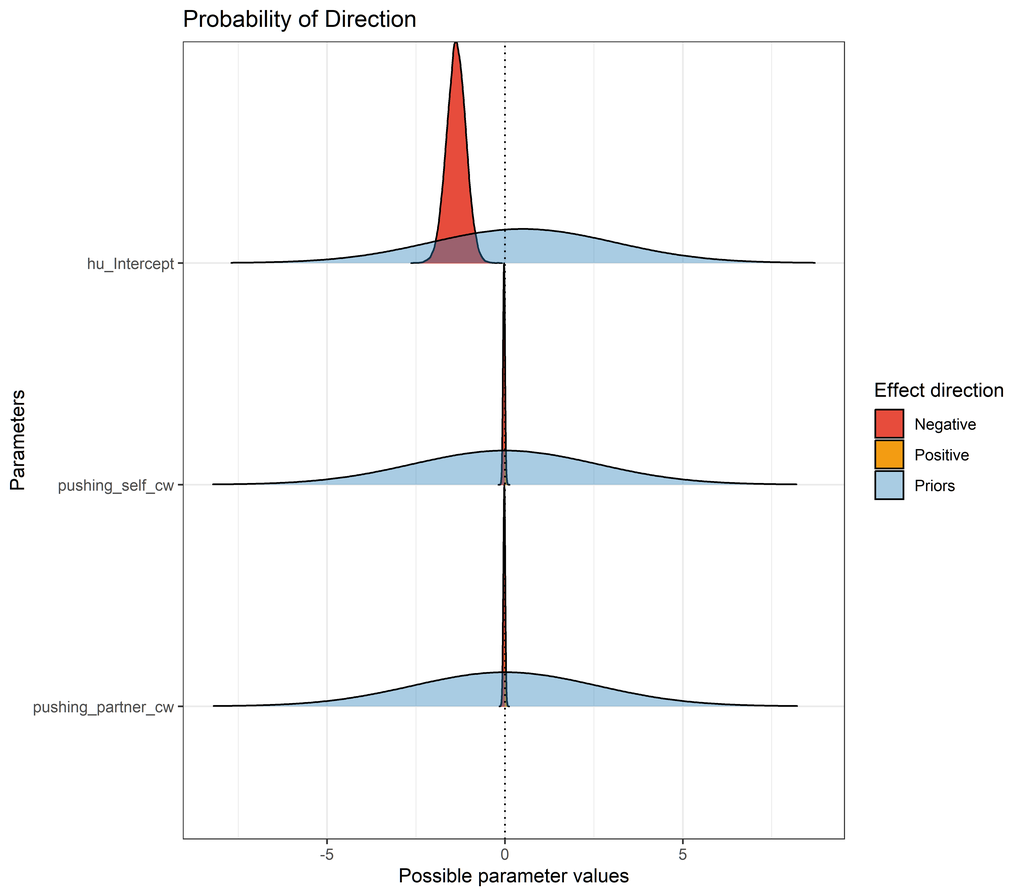

```r
# Plot continuous part of model

variable <- c(
  '(Intercept)',
  'b_persuasion_self_cw',
  'b_persuasion_partner_cw',
  'b_pressure_self_cw',
  'b_pressure_partner_cw',
  'b_pushing_self_cw',
  'b_pushing_partner_cw'
)


plot(
  bayestestR::p_direction(pa_sub, parameter = variable),
  priors = TRUE
) + theme_bw()
```

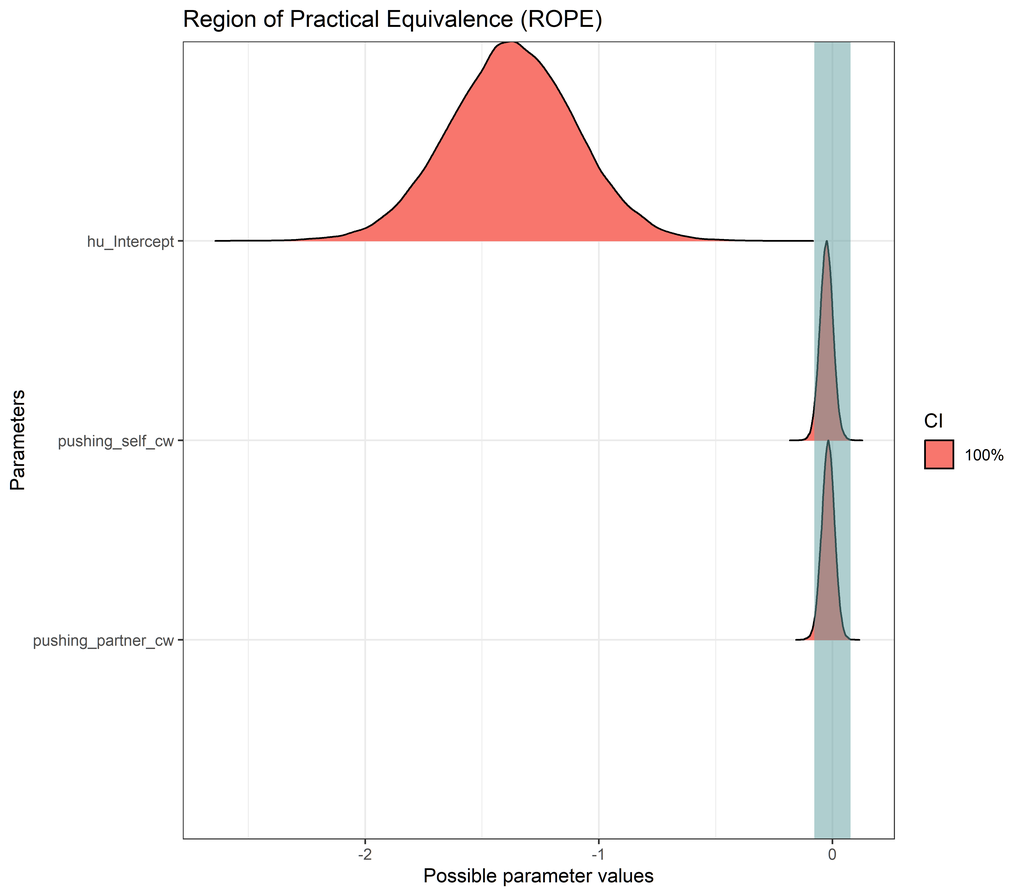

```r
plot(
  bayestestR::rope(
    pa_sub,
    parameter = variable,
    range = rope_range_continuous,
    verbose = F,
    ci = 1
  )
) + theme_bw()
```

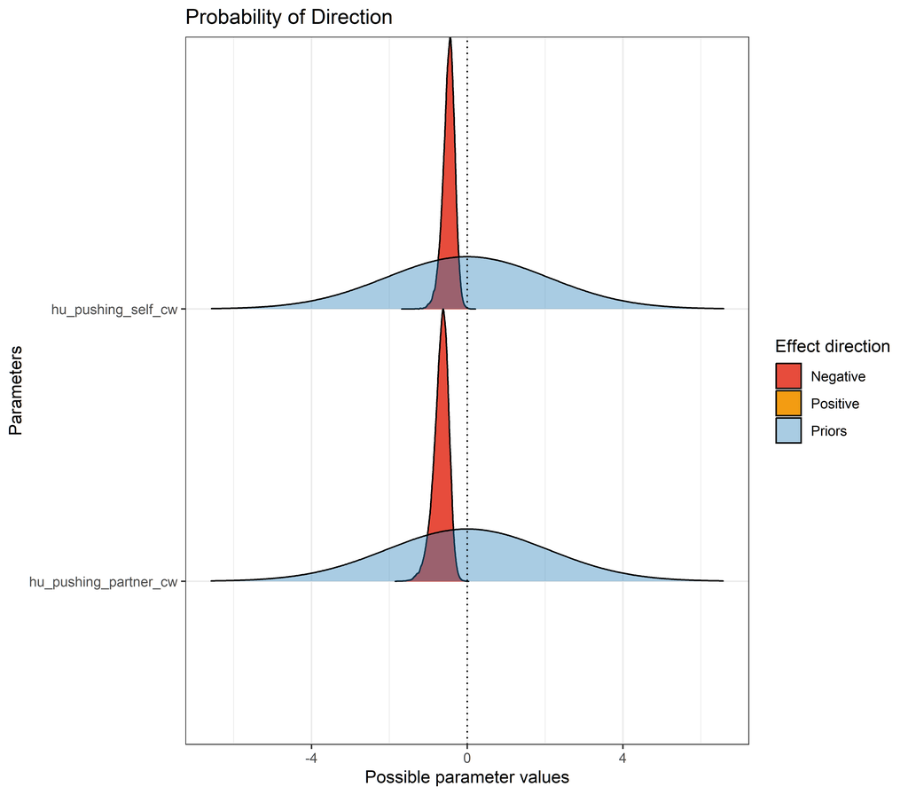

```r
# Hurdle part of the model
variable <- c(
  'b_hu_persuasion_self_cw',
  'b_hu_persuasion_partner_cw',
  'b_hu_pressure_self_cw',
  'b_hu_pressure_partner_cw',
  'b_hu_pushing_self_cw',
  'b_hu_pushing_partner_cw'
)

plot(
  bayestestR::p_direction(pa_sub, parameter = variable),
  priors = TRUE
) + theme_bw()
```

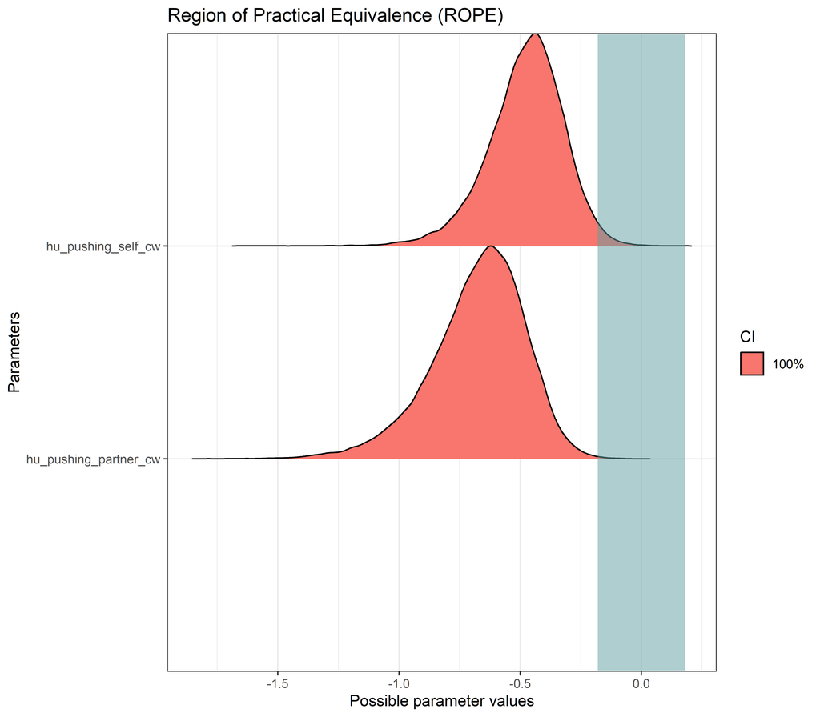

```r
# The rope range for the bernoulli part of the model is -0.18, 0.18
plot(
  bayestestR::rope(pa_sub, parameter = variable, range = c(-0.18, 0.18), ci = 1),
  verbose = FALSE
) + theme_bw()
```

## Device Based MVPA

### Lognormal Model

```r
formula <- bf(
  pa_obj ~

    pushing_self_cw + pushing_partner_cw +
    pushing_self_cb + pushing_partner_cb +

    #plan_self + plan_partner +
    day + weartime_self_cw + weartime_self_cb +

    # Random effects
    (1 | dd | coupleID)

  + (1 + pushing_self_cw + pushing_partner_cw | d_u | coupleID:userID)

  , decomp = 'QR'
  #, autocor = autocor_str
)



prior1 <- c(
  brms::set_prior("normal(0, 2.5)", class = "b")
  , brms::set_prior("normal(0, 50)", class = "Intercept")
  , brms::set_prior("normal(0, 2)", class = "sd", group = "coupleID", lb = 0)
  , brms::set_prior("student_t(3, 0, 2.5)", class = "sigma", lb = 0)
)


#brms::validate_prior(
#  prior1,
#  formula = formula,
#  data = df_double,
#  family = lognormal()
#  )

#df_minimal <- df_double[, c("AorB", all.vars(as.formula(formula)))]

pa_obj_log <- my_brm(
  mi = use_mi,
  imputed_data = implist,

  formula = formula,
  prior = prior1,
  data = df_double,
  family = lognormal(),
  control = list(adapt_delta = 0.9),
  iter = iterations,
  warmup = warmup,
  chains = 4,
  cores = 4,
  seed = 7777,
  file = file.path("models_cache_brms", paste0("pa_obj_log_gaussian", suffix_onlypushing))
)
pa_obj_log_digest <- digest::digest(pa_obj_log)
```

```r
# rope range for lognormal model
rope_factor <- sd(log(pa_obj_log$data$pa_obj))
rope_range_log = c(-0.1 * rope_factor, 0.1 * rope_factor)

summary_pa_obj <- summarize_brms(
  pa_obj_log,
  stats_to_report = stats_to_report,
  rope_range = rope_range_log,
  model_rows_fixed = model_rows_fixed,
  model_rows_random = model_rows_random,
  model_rownames_fixed = model_rownames_fixed,
  model_rownames_random = model_rownames_random,
  exponentiate = T)
summary_pa_obj %>%
  print_df(rows_to_pack = rows_to_pack)
```

|  | exp(Est.) | SE | 95% CI | pd | ROPE | inside ROPE | Rhat | Bulk_ESS | Tail_ESS |
| --- | --- | --- | --- | --- | --- | --- | --- | --- | --- |
| Intercept | 123.93*** | 7.39 | [109.86, 139.41] | 1.000 | [0.94, 1.06] | 0.000 | 1.000 | 22518 | 26430 |
| **Within-Person Effects** |  |  |  |  |  |  |  |  |  |
| Daily individual’s experienced persuasion | NA | NA | NA | NA | NA | NA | NA | NA | NA |
| Daily partner’s experienced persuasion | NA | NA | NA | NA | NA | NA | NA | NA | NA |
| Daily individual’s experienced pressure | NA | NA | NA | NA | NA | NA | NA | NA | NA |
| Daily partner’s experienced pressure | NA | NA | NA | NA | NA | NA | NA | NA | NA |
| Daily individual’s experienced pushing | 1.02 | 0.03 | [ 0.97, 1.08] | 0.828 | [0.94, 1.06] | 0.930 | 1.000 | 30249 | 28251 |
| Daily partner’s experienced pushing | 1.02 | 0.02 | [ 0.98, 1.06] | 0.805 | [0.94, 1.06] | 0.987 | 1.000 | 55598 | 30822 |
| Day | 0.97 | 0.05 | [ 0.88, 1.08] | 0.704 | [0.94, 1.06] | 0.687 | 1.000 | 66455 | 30652 |
| Own action plan | NA | NA | NA | NA | NA | NA | NA | NA | NA |
| Partner action plan | NA | NA | NA | NA | NA | NA | NA | NA | NA |
| Daily wear time | 1.00** | 0.00 | [ 1.00, 1.00] | 0.998 | [0.94, 1.06] | 1.000 | 1.000 | 72449 | 30641 |
| **Between-Person Effects** |  |  |  |  |  |  |  |  |  |
| Mean individual’s experienced persuasion | NA | NA | NA | NA | NA | NA | NA | NA | NA |
| Mean partner’s experienced persuasion | NA | NA | NA | NA | NA | NA | NA | NA | NA |
| Mean individual’s experienced pressure | NA | NA | NA | NA | NA | NA | NA | NA | NA |
| Mean partner’s experienced pressure | NA | NA | NA | NA | NA | NA | NA | NA | NA |
| Mean individual’s experienced pushing | 0.98 | 0.09 | [ 0.82, 1.17] | 0.597 | [0.94, 1.06] | 0.496 | 1.000 | 25642 | 28369 |
| Mean partner’s experienced pushing | 1.04 | 0.09 | [ 0.87, 1.25] | 0.682 | [0.94, 1.06] | 0.470 | 1.000 | 24791 | 27892 |
| Mean wear time | 1.00 | 0.00 | [ 1.00, 1.00] | 0.525 | [0.94, 1.06] | 1.000 | 1.000 | 20525 | 26257 |
| **Random Effects (Level 3 - Couple)** |  |  |  |  |  |  |  |  |  |
| L3:sd(Intercept) | 0.25 | 0.06 | [0.13, 0.37] | NA | NA | NA | 1.000 | 7811 | 7259 |
| **Random Effects (Level 2 - Couple:Person)** |  |  |  |  |  |  |  |  |  |
| L2:sd(Intercept) | 0.24 | 0.04 | [0.17, 0.34] | NA | NA | NA | 1.001 | 8324 | 10868 |
| L2:sd(Daily individual’s experienced persuasion) | NA | NA | NA | NA | NA | NA | NA | NA | NA |
| L2:sd(Daily partner’s experienced persuasion) | NA | NA | NA | NA | NA | NA | NA | NA | NA |
| L2:sd(Daily individual’s experienced pressure) | NA | NA | NA | NA | NA | NA | NA | NA | NA |
| L2:sd(Daily partner’s experienced pressure) | NA | NA | NA | NA | NA | NA | NA | NA | NA |
| L2:sd(Daily individual’s experienced pushing) | 0.10 | 0.03 | [0.03, 0.16] | NA | NA | NA | 1.001 | 9346 | 6524 |
| L2:sd(Daily partner’s experienced pushing) | 0.03 | 0.03 | [0.00, 0.09] | NA | NA | NA | 1.000 | 15888 | 20463 |
| **Additional Parameters** |  |  |  |  |  |  |  |  |  |
| sigma | 0.52 | 0.01 | [0.50, 0.54] | NA | NA | NA | 1.000 | 43058 | 29798 |

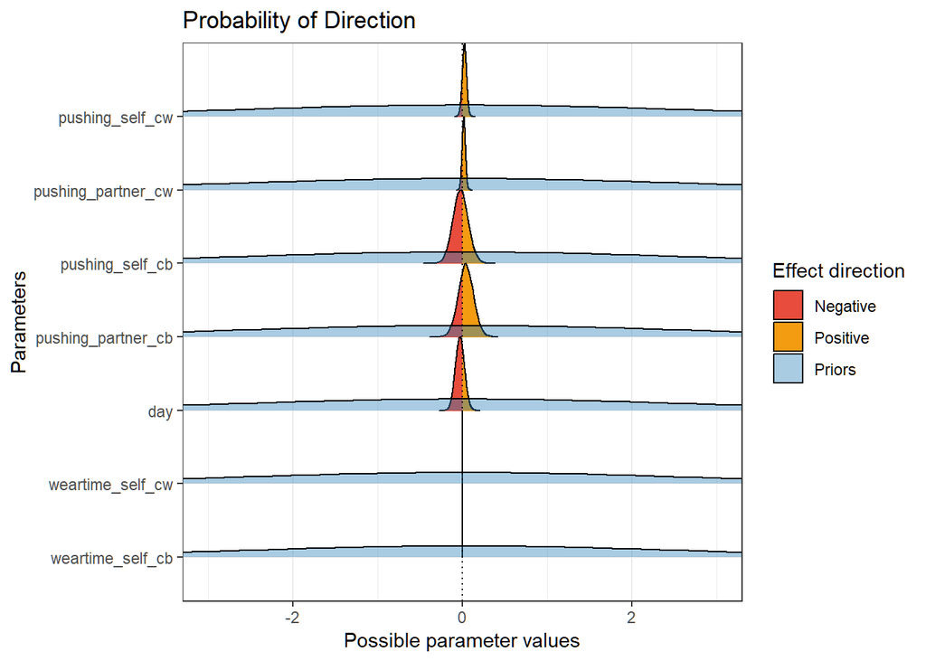

```r
plot(
  bayestestR::p_direction(pa_obj_log),
  priors = TRUE
) +
  coord_cartesian(xlim = c(-3, 3)) +
  theme_bw()
```

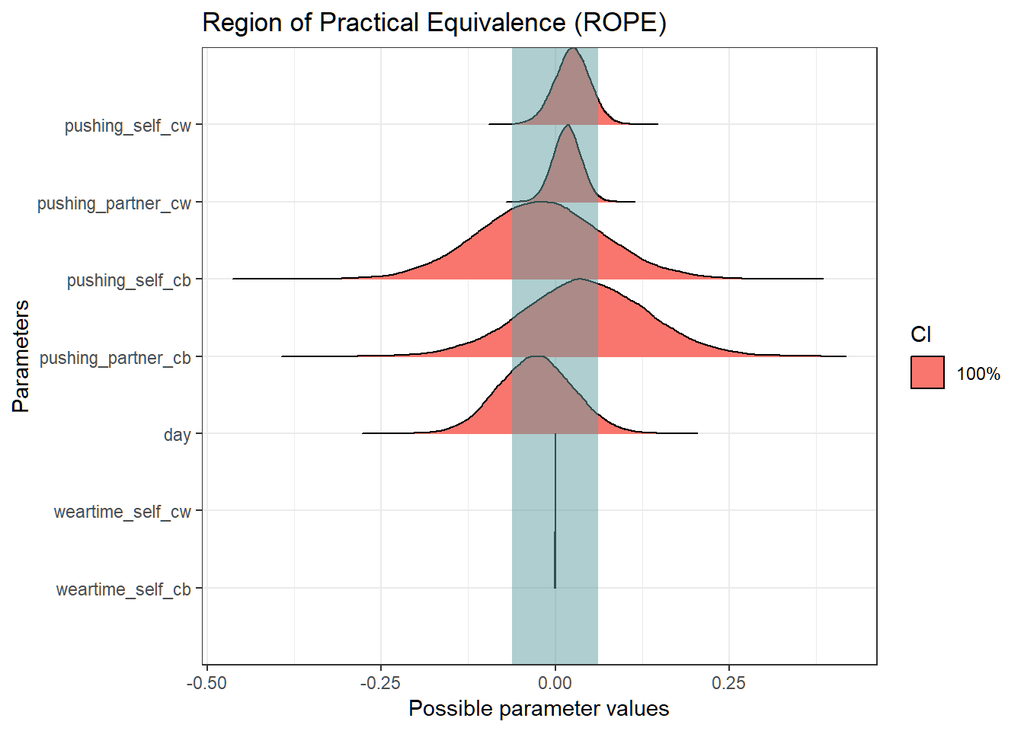

```r
plot(
  bayestestR::rope(pa_obj_log, range = rope_range_log, ci = 1)
) + theme_bw()
```

```r
# Nothing significant, no plots
```

## Affect

### Gaussian

```r
formula <- bf(
  aff ~
    pushing_self_cw + pushing_partner_cw +
    pushing_self_cb + pushing_partner_cb +

    #plan_self + plan_partner +
    day +

    # Random effects
    (1 | dd | coupleID)

  + (1 + pushing_self_cw + pushing_partner_cw | d_u | coupleID:userID)

  , decomp = 'QR'
  #, autocor = autocor_str
)


prior1 <- c(
  brms::set_prior("normal(0, 5)", class = "b")
  ,brms::set_prior("normal(0, 20)", class = "Intercept", lb=1, ub=6)
  , brms::set_prior("normal(0, 2)", class = "sd", group = "coupleID", lb = 0)
  , brms::set_prior("student_t(3, 0, 2.5)", class = "sigma", lb = 0)
)

#brms::validate_prior(
#  prior1,
#  formula = formula,
#  data = df_double,
#  family = gaussian()
#  )

#df_minimal <- df_double[, c("AorB", all.vars(as.formula(formula)))]

mood_gauss <- my_brm(
  mi = use_mi,
  imputed_data = implist,

  formula = formula,
  prior = prior1,
  data = df_double,
  family = gaussian(),
  #control = list(adapt_delta = 0.95, max_treedepth = 15),
  iter = iterations,
  warmup = warmup,
  chains = 4,
  cores = 4,
  seed = 7777,
  file = file.path("models_cache_brms", paste0("mood_gauss", suffix_onlypushing))
)
mood_gauss_digest <- digest::digest(mood_gauss)
```

```r
summary_mood <- summarize_brms(
  mood_gauss,
  stats_to_report = stats_to_report,
  model_rows_fixed = model_rows_fixed,
  model_rows_random = model_rows_random,
  model_rownames_fixed = model_rownames_fixed,
  model_rownames_random = model_rownames_random,
  exponentiate = F)
summary_mood %>%
  print_df(rows_to_pack = rows_to_pack)
```

|  | Est. | SE | 95% CI | pd | ROPE | inside ROPE | Rhat | Bulk_ESS | Tail_ESS |
| --- | --- | --- | --- | --- | --- | --- | --- | --- | --- |
| Intercept | 3.78*** | 0.11 | [ 3.57, 3.98] | 1.000 | [-0.11, 0.11] | 0.000 | 1.000 | 15488 | 17953 |
| **Within-Person Effects** |  |  |  |  |  |  |  |  |  |
| Daily individual’s experienced persuasion | NA | NA | NA | NA | NA | NA | NA | NA | NA |
| Daily partner’s experienced persuasion | NA | NA | NA | NA | NA | NA | NA | NA | NA |
| Daily individual’s experienced pressure | NA | NA | NA | NA | NA | NA | NA | NA | NA |
| Daily partner’s experienced pressure | NA | NA | NA | NA | NA | NA | NA | NA | NA |
| Daily individual’s experienced pushing | 0.01 | 0.03 | [-0.05, 0.08] | 0.663 | [-0.11, 0.11] | 0.996 | 1.000 | 20550 | 23723 |
| Daily partner’s experienced pushing | 0.09* | 0.04 | [ 0.02, 0.16] | 0.992 | [-0.11, 0.11] | 0.727 | 1.000 | 20340 | 26409 |
| Day | 0.28*** | 0.08 | [ 0.11, 0.44] | 1.000 | [-0.11, 0.11] | 0.021 | 1.001 | 32199 | 18398 |
| Own action plan | NA | NA | NA | NA | NA | NA | NA | NA | NA |
| Partner action plan | NA | NA | NA | NA | NA | NA | NA | NA | NA |
| Daily wear time | NA | NA | NA | NA | NA | NA | NA | NA | NA |
| **Between-Person Effects** |  |  |  |  |  |  |  |  |  |
| Mean individual’s experienced persuasion | NA | NA | NA | NA | NA | NA | NA | NA | NA |
| Mean partner’s experienced persuasion | NA | NA | NA | NA | NA | NA | NA | NA | NA |
| Mean individual’s experienced pressure | NA | NA | NA | NA | NA | NA | NA | NA | NA |
| Mean partner’s experienced pressure | NA | NA | NA | NA | NA | NA | NA | NA | NA |
| Mean individual’s experienced pushing | 0.16 | 0.16 | [-0.15, 0.48] | 0.851 | [-0.11, 0.11] | 0.323 | 1.000 | 13999 | 19631 |
| Mean partner’s experienced pushing | 0.04 | 0.16 | [-0.27, 0.36] | 0.612 | [-0.11, 0.11] | 0.493 | 1.000 | 15032 | 20029 |
| Mean wear time | NA | NA | NA | NA | NA | NA | NA | NA | NA |
| **Random Effects (Level 3 - Couple)** |  |  |  |  |  |  |  |  |  |
| L3:sd(Intercept) | 0.38 | 0.13 | [0.05, 0.61] | NA | NA | NA | 1.001 | 3216 | 3903 |
| **Random Effects (Level 2 - Couple:Person)** |  |  |  |  |  |  |  |  |  |
| L2:sd(Intercept) | 0.58 | 0.09 | [0.43, 0.78] | NA | NA | NA | 1.001 | 4058 | 2733 |
| L2:sd(Daily individual’s experienced persuasion) | NA | NA | NA | NA | NA | NA | NA | NA | NA |
| L2:sd(Daily partner’s experienced persuasion) | NA | NA | NA | NA | NA | NA | NA | NA | NA |
| L2:sd(Daily individual’s experienced pressure) | NA | NA | NA | NA | NA | NA | NA | NA | NA |
| L2:sd(Daily partner’s experienced pressure) | NA | NA | NA | NA | NA | NA | NA | NA | NA |
| L2:sd(Daily individual’s experienced pushing) | 0.11 | 0.04 | [0.02, 0.20] | NA | NA | NA | 1.000 | 13841 | 8795 |
| L2:sd(Daily partner’s experienced pushing) | 0.13 | 0.04 | [0.06, 0.22] | NA | NA | NA | 1.000 | 14951 | 13448 |
| **Additional Parameters** |  |  |  |  |  |  |  |  |  |
| sigma | 0.85 | 0.02 | [0.81, 0.88] | NA | NA | NA | 1.000 | 29137 | 19991 |

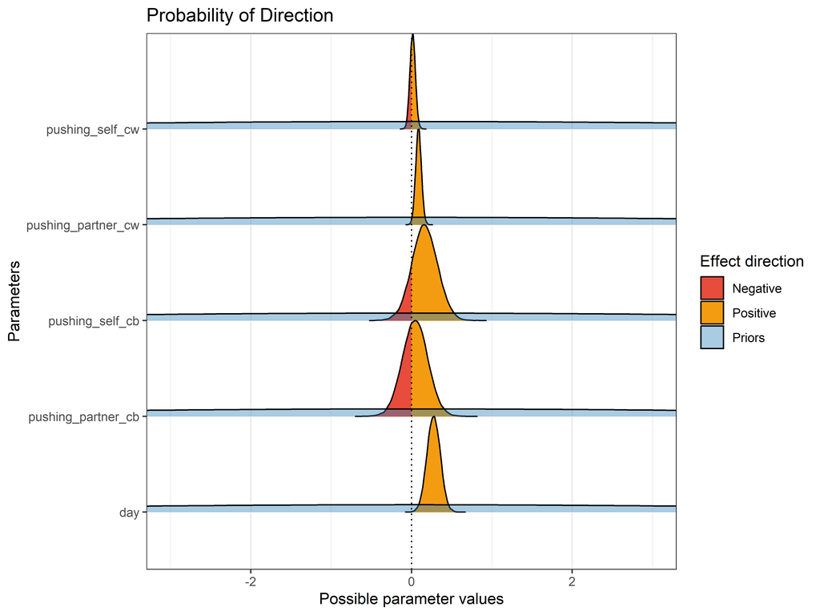

```r
plot(
  bayestestR::p_direction(mood_gauss),
  priors = TRUE
)  +
  coord_cartesian(xlim = c(-3, 3)) +
  theme_bw()
```

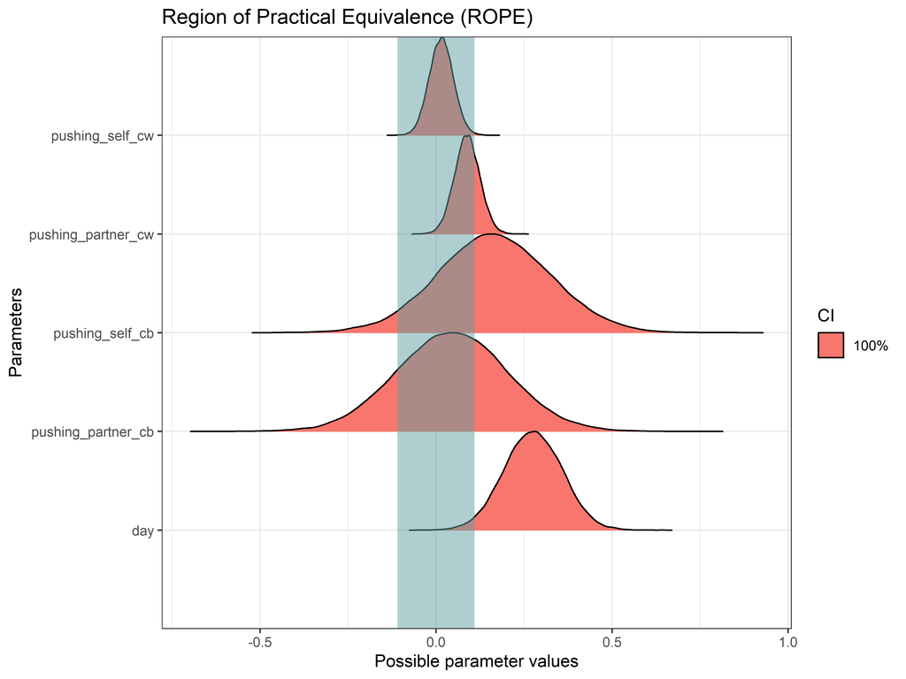

```r
plot(
  bayestestR::rope(mood_gauss, ci = 1)
) + theme_bw()
```

## Reactance

### Ordinal

```r
df_double$reactance_ordinal <- factor(df_double$reactance,
                                      levels = 0:5,
                                      ordered = TRUE)

formula <- bf(
  reactance_ordinal ~
    pushing_self_cw + pushing_partner_cw +
    pushing_self_cb + pushing_partner_cb +

    #plan_self + plan_partner +
    day +

    # Random effects
    (1 | dd | coupleID)

  + (1 + pushing_self_cw + pushing_partner_cw | d_u | coupleID:userID)

  , decomp = 'QR'
  #, autocor = autocor_str
)


prior1 <- c(
  brms::set_prior("normal(0, 2.5)", class = "b")
  , brms::set_prior("normal(0, 2)", class = "sd", group = "coupleID", lb = 0)
)


#brms::validate_prior(
#  prior1,
#  formula = formula,
#  data = df_double,
#  family = cumulative() # HURDLE_CUMULATIVE
#  )


#df_minimal <- df_double[, c("AorB", all.vars(as.formula(formula)))]

reactance_ordinal <- my_brm(
  mi = use_mi,
  imputed_data = implist,

  formula = formula,
  prior = prior1,
  data = df_double,
  family = brms::cumulative(),
  control = list(adapt_delta = 0.90),
  iter = iterations,
  warmup = warmup,
  chains = 4,
  cores = 4,
  seed = 7777
  , file = file.path("models_cache_brms", paste0("reactance_ordinal", suffix_onlypushing))
)
reactance_ordinal_digest <- digest::digest(reactance_ordinal)
```

### Binary

```r
introduce_binary_reactance <- function(data) {
  data$is_reactance <- factor(data$reactance > 0, levels = c(FALSE, TRUE), labels = c(0, 1))
  return(data)
}



df_double <- introduce_binary_reactance(df_double)
if (use_mi) {
  for (i in seq_along(implist)) {
    implist[[i]] <- introduce_binary_reactance(implist[[i]])
  }
}


formula <- bf(
  is_reactance ~
    pushing_self_cw + pushing_partner_cw +
    pushing_self_cb + pushing_partner_cb +

    #plan_self + plan_partner +
    day +

    # Random effects
    (1 | dd | coupleID)

  + (1 + pushing_self_cw + pushing_partner_cw | d_u | coupleID:userID)

  , decomp = 'QR'
  #, autocor = autocor_str
  )



prior1 <- c(
  brms::set_prior("normal(0, 2.5)", class = "b")
  , brms::set_prior("normal(0, 10)", class = "Intercept", lb=0, ub=5)
  , brms::set_prior("normal(0, 2)", class = "sd", group = "coupleID", lb = 0)
)


#brms::validate_prior(
#  prior1,
#  formula = formula,
#  data = df_double,
#  family = bernoulli()
#  )



#df_minimal <- df_double[, c("AorB", all.vars(as.formula(formula)))]

is_reactance <- my_brm(
  mi = use_mi,
  imputed_data = implist,

  formula = formula,
  prior = prior1,
  data = df_double,
  family = brms::bernoulli(),
  control = list(adapt_delta = 0.95),
  iter = iterations,
  warmup = warmup,
  chains = 4,
  cores = 4,
  seed = 7777,
  file = file.path("models_cache_brms", paste0("is_reactance", suffix_onlypushing))
  #, file_refit = 'always'
)
is_reactance_digest <- digest::digest(is_reactance)
```

```r
summary_is_reactance <- summarize_brms(
  is_reactance,
  stats_to_report = stats_to_report,
  model_rows_fixed = model_rows_fixed,
  model_rows_random = model_rows_random,
  model_rownames_fixed = model_rownames_fixed,
  model_rownames_random = model_rownames_random,
  exponentiate = T)

summary_is_reactance %>%
  print_df(rows_to_pack = rows_to_pack)
```

|  | OR | SE | 95% CI | pd | ROPE | inside ROPE | Rhat | Bulk_ESS | Tail_ESS |
| --- | --- | --- | --- | --- | --- | --- | --- | --- | --- |
| Intercept | 0.39** | 0.12 | [0.21, 0.70] | 0.999 | [0.83, 1.20] | 0.005 | 1.000 | 29379 | 28882 |
| **Within-Person Effects** |  |  |  |  |  |  |  |  |  |
| Daily individual’s experienced persuasion | NA | NA | NA | NA | NA | NA | NA | NA | NA |
| Daily partner’s experienced persuasion | NA | NA | NA | NA | NA | NA | NA | NA | NA |
| Daily individual’s experienced pressure | NA | NA | NA | NA | NA | NA | NA | NA | NA |
| Daily partner’s experienced pressure | NA | NA | NA | NA | NA | NA | NA | NA | NA |
| Daily individual’s experienced pushing | 1.38* | 0.20 | [1.05, 1.96] | 0.990 | [0.83, 1.20] | 0.157 | 1.000 | 24965 | 22743 |
| Daily partner’s experienced pushing | 1.00 | 0.17 | [0.73, 1.47] | 0.510 | [0.83, 1.20] | 0.716 | 1.000 | 30522 | 24132 |
| Day | 1.43 | 0.77 | [0.49, 4.17] | 0.745 | [0.83, 1.20] | 0.213 | 1.000 | 57833 | 30991 |
| Own action plan | NA | NA | NA | NA | NA | NA | NA | NA | NA |
| Partner action plan | NA | NA | NA | NA | NA | NA | NA | NA | NA |
| Daily wear time | NA | NA | NA | NA | NA | NA | NA | NA | NA |
| **Between-Person Effects** |  |  |  |  |  |  |  |  |  |
| Mean individual’s experienced persuasion | NA | NA | NA | NA | NA | NA | NA | NA | NA |
| Mean partner’s experienced persuasion | NA | NA | NA | NA | NA | NA | NA | NA | NA |
| Mean individual’s experienced pressure | NA | NA | NA | NA | NA | NA | NA | NA | NA |
| Mean partner’s experienced pressure | NA | NA | NA | NA | NA | NA | NA | NA | NA |
| Mean individual’s experienced pushing | 10.13*** | 7.21 | [2.96, 51.93] | 1.000 | [0.83, 1.20] | 0.000 | 1.000 | 21258 | 23550 |
| Mean partner’s experienced pushing | 2.12 | 1.47 | [0.53, 8.69] | 0.861 | [0.83, 1.20] | 0.116 | 1.000 | 24671 | 26676 |
| Mean wear time | NA | NA | NA | NA | NA | NA | NA | NA | NA |
| **Random Effects (Level 3 - Couple)** |  |  |  |  |  |  |  |  |  |
| L3:sd(Intercept) | 1.39 | 0.43 | [0.29, 2.28] | NA | NA | NA | 1.000 | 6299 | 5280 |
| **Random Effects (Level 2 - Couple:Person)** |  |  |  |  |  |  |  |  |  |
| L2:sd(Intercept) | 1.27 | 0.47 | [0.45, 2.33] | NA | NA | NA | 1.000 | 6112 | 10879 |
| L2:sd(Daily individual’s experienced persuasion) | NA | NA | NA | NA | NA | NA | NA | NA | NA |
| L2:sd(Daily partner’s experienced persuasion) | NA | NA | NA | NA | NA | NA | NA | NA | NA |
| L2:sd(Daily individual’s experienced pressure) | NA | NA | NA | NA | NA | NA | NA | NA | NA |
| L2:sd(Daily partner’s experienced pressure) | NA | NA | NA | NA | NA | NA | NA | NA | NA |
| L2:sd(Daily individual’s experienced pushing) | 0.33 | 0.23 | [0.02, 0.88] | NA | NA | NA | 1.000 | 11717 | 16129 |
| L2:sd(Daily partner’s experienced pushing) | 0.30 | 0.25 | [0.02, 0.93] | NA | NA | NA | 1.000 | 13724 | 17521 |
| **Additional Parameters** |  |  |  |  |  |  |  |  |  |
| sigma | NA | NA | NA | NA | NA | NA | NA | NA | NA |

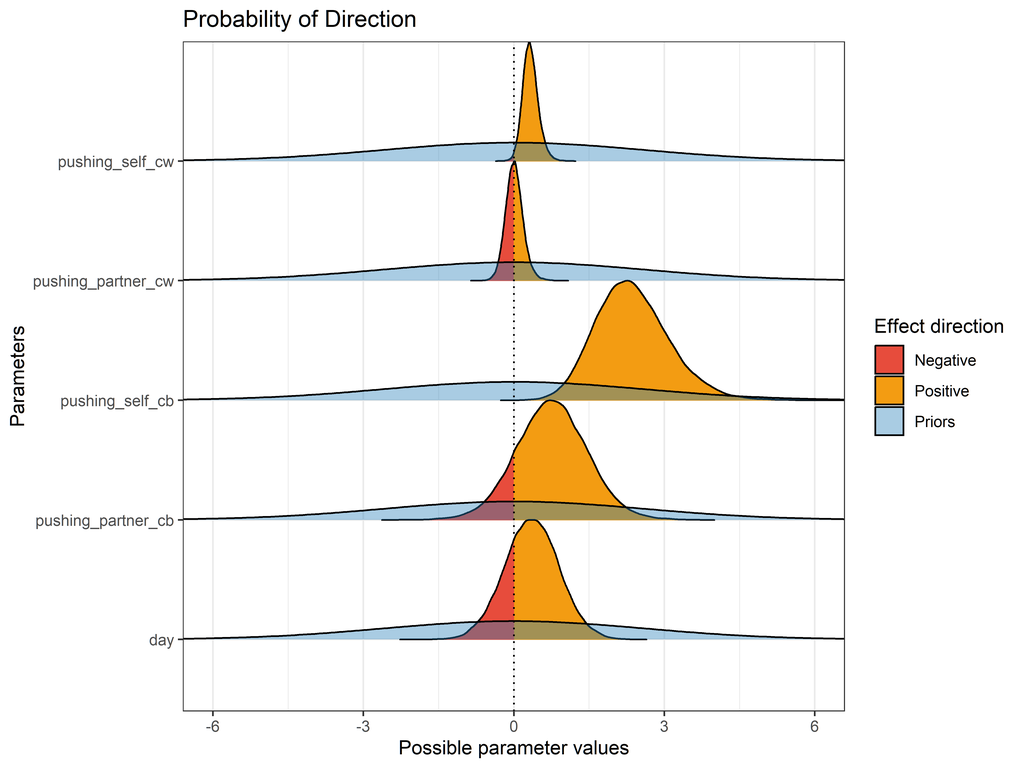

```r
plot(
  bayestestR::p_direction(is_reactance),
  priors = TRUE
) +
  coord_cartesian(xlim = c(-6, 6)) +
  theme_bw()
```

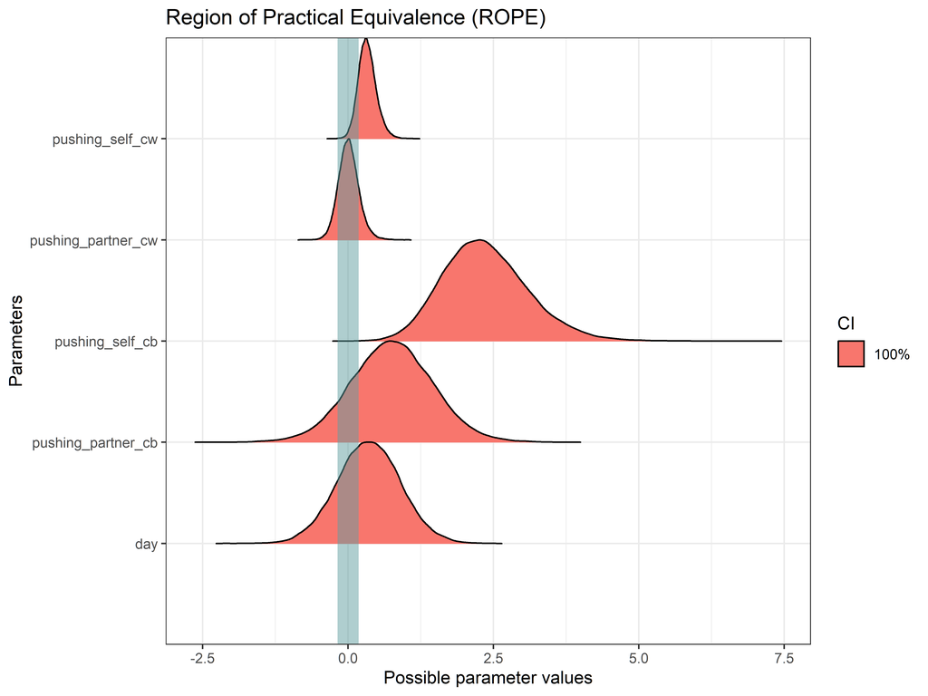

```r
plot(
  bayestestR::rope(is_reactance, ci = 1)
) + theme_bw()
```

# Report All Models

```r
summary_all_models <- report_side_by_side(
  pa_sub,
  pa_obj_log,
  mood_gauss,
  is_reactance,

  stats_to_report = c('CI'),
  model_rows_random = model_rows_random,
  model_rows_fixed = model_rows_fixed,
  model_rownames_random = model_rownames_random,
  model_rownames_fixed = model_rownames_fixed
)
```

[1] “pa_sub”

[1] “pa_obj_log”

[1] “mood_gauss”

[1] “is_reactance”

```r
summary_all_models <- summary_all_models %>%
  print_df(rows_to_pack = rows_to_pack) %>%
  add_header_above(
    c(
      " ", "Hurdle Component" = 2, "Non-Zero Component" = 2,
      " " = 6
    )
  ) %>%
  add_header_above(
    c(" ", "Subjective MVPA Hurdle Lognormal" = 4,
      "Device-Based MVPA Log (Gaussian)" = 2,
      "Mood Gaussian" = 2,
      #"Reactance Ordinal" = 2,
      "Reactance Dichotome" = 2
    )
  )

export_xlsx(
  summary_all_models,
  rows_to_pack = rows_to_pack,
  file.path("Output", paste0("AllModels", suffix_onlypushing, ".xlsx")),
  merge_option = 'header',
  simplify_2nd_row = TRUE,
  line_above_rows = c(1,2),
  line_below_rows = c(-1)
)


summary_all_models
```

|  | Subjective MVPA Hurdle Lognormal Hurdle Component exp(Est.)_hu pa_sub | Subjective MVPA Hurdle Lognormal Hurdle Component 95% CI_hu pa_sub | Subjective MVPA Hurdle Lognormal Non-Zero Component exp(Est.)_nonzero pa_sub | Subjective MVPA Hurdle Lognormal Non-Zero Component 95% CI_nonzero pa_sub | Device-Based MVPA Log (Gaussian) exp(Est.) pa_obj_log | Device-Based MVPA Log (Gaussian) 95% CI pa_obj_log | Mood Gaussian Est. mood_gauss | Mood Gaussian 95% CI mood_gauss | Reactance Dichotome OR is_reactance | Reactance Dichotome 95% CI is_reactance |
| --- | --- | --- | --- | --- | --- | --- | --- | --- | --- | --- |
| Intercept | 3.93*** | [ 2.32, 6.72] | 56.49*** | [48.38, 65.73] | 123.93*** | [109.86, 139.41] | 3.78*** | [ 3.57, 3.98] | 0.39** | [0.21, 0.70] |
| **Within-Person Effects** |  |  |  |  |  |  |  |  |  |  |
| Daily individual’s experienced persuasion | NA | NA | NA | NA | NA | NA | NA | NA | NA | NA |
| Daily partner’s experienced persuasion | NA | NA | NA | NA | NA | NA | NA | NA | NA | NA |
| Daily individual’s experienced pressure | NA | NA | NA | NA | NA | NA | NA | NA | NA | NA |
| Daily partner’s experienced pressure | NA | NA | NA | NA | NA | NA | NA | NA | NA | NA |
| Daily individual’s experienced pushing | 1.59** | [ 1.23, 2.28] | 0.97 | [ 0.92, 1.03] | 1.02 | [ 0.97, 1.08] | 0.01 | [-0.05, 0.08] | 1.38* | [1.05, 1.96] |
| Daily partner’s experienced pushing | 1.92*** | [ 1.42, 3.09] | 0.98 | [ 0.93, 1.04] | 1.02 | [ 0.98, 1.06] | 0.09* | [ 0.02, 0.16] | 1.00 | [0.73, 1.47] |
| Day | 0.59* | [ 0.36, 0.97] | 0.91 | [ 0.78, 1.05] | 0.97 | [ 0.88, 1.08] | 0.28*** | [ 0.11, 0.44] | 1.43 | [0.49, 4.17] |
| Own action plan | NA | NA | NA | NA | NA | NA | NA | NA | NA | NA |
| Partner action plan | NA | NA | NA | NA | NA | NA | NA | NA | NA | NA |
| Daily wear time | NA | NA | NA | NA | 1.00** | [ 1.00, 1.00] | NA | NA | NA | NA |
| **Between-Person Effects** |  |  |  |  |  |  |  |  |  |  |
| Mean individual’s experienced persuasion | NA | NA | NA | NA | NA | NA | NA | NA | NA | NA |
| Mean partner’s experienced persuasion | NA | NA | NA | NA | NA | NA | NA | NA | NA | NA |
| Mean individual’s experienced pressure | NA | NA | NA | NA | NA | NA | NA | NA | NA | NA |
| Mean partner’s experienced pressure | NA | NA | NA | NA | NA | NA | NA | NA | NA | NA |
| Mean individual’s experienced pushing | 0.47* | [ 0.24, 0.85] | 1.23 | [ 0.94, 1.58] | 0.98 | [ 0.82, 1.17] | 0.16 | [-0.15, 0.48] | 10.13*** | [2.96, 51.93] |
| Mean partner’s experienced pushing | 0.62 | [ 0.31, 1.14] | 1.09 | [ 0.84, 1.42] | 1.04 | [ 0.87, 1.25] | 0.04 | [-0.27, 0.36] | 2.12 | [0.53, 8.69] |
| Mean wear time | NA | NA | NA | NA | 1.00 | [ 1.00, 1.00] | NA | NA | NA | NA |
| **Random Effects (Level 3 - Couple)** |  |  |  |  |  |  |  |  |  |  |
| L3:sd(Intercept) | 1.27 | [0.93, 1.77] | 0.36 | [0.26, 0.49] | 0.25 | [0.13, 0.37] | 0.38 | [0.05, 0.61] | 1.39 | [0.29, 2.28] |
| **Random Effects (Level 2 - Couple:Person)** |  |  |  |  |  |  |  |  |  |  |
| L2:sd(Intercept) | 0.25 | [0.02, 0.61] | 0.10 | [0.01, 0.22] | 0.24 | [0.17, 0.34] | 0.58 | [0.43, 0.78] | 1.27 | [0.45, 2.33] |
| L2:sd(Daily individual’s experienced persuasion) | NA | NA | NA | NA | NA | NA | NA | NA | NA | NA |
| L2:sd(Daily partner’s experienced persuasion) | NA | NA | NA | NA | NA | NA | NA | NA | NA | NA |
| L2:sd(Daily individual’s experienced pressure) | NA | NA | NA | NA | NA | NA | NA | NA | NA | NA |
| L2:sd(Daily partner’s experienced pressure) | NA | NA | NA | NA | NA | NA | NA | NA | NA | NA |
| L2:sd(Daily individual’s experienced pushing) | 0.47 | [0.03, 1.09] | 0.05 | [0.00, 0.14] | 0.10 | [0.03, 0.16] | 0.11 | [0.02, 0.20] | 0.33 | [0.02, 0.88] |
| L2:sd(Daily partner’s experienced pushing) | 0.59 | [0.04, 1.41] | 0.06 | [0.00, 0.15] | 0.03 | [0.00, 0.09] | 0.13 | [0.06, 0.22] | 0.30 | [0.02, 0.93] |
| **Additional Parameters** |  |  |  |  |  |  |  |  |  |  |
| sigma | NA | NA | 0.67 | [0.64, 0.70] | 0.52 | [0.50, 0.54] | 0.85 | [0.81, 0.88] | NA | NA |

```r
report::report_system()
```

Analyses were conducted using the R Statistical language (version 4.4.2; R Core Team, 2024) on Windows 11 x64 (build 26100)

```r
report::report_packages()
```

- beepr (version 2.0; Bååth R, 2024)
- R.methodsS3 (version 1.8.2; Bengtsson H, 2003)
- R.oo (version 1.27.0; Bengtsson H, 2003)
- R.utils (version 2.12.3; Bengtsson H, 2023)
- brms (version 2.22.0; Bürkner P, 2017)
- digest (version 0.6.37; Eddelbuettel D, 2024)
- Rcpp (version 1.0.13.1; Eddelbuettel D et al., 2024)
- bayesplot (version 1.11.1; Gabry J, Mahr T, 2024)
- lubridate (version 1.9.3; Grolemund G, Wickham H, 2011)
- DHARMa (version 0.4.7; Hartig F, 2024)
- wbCorr (version 0.1.22; Küng P, 2023)
- see (version 0.9.0; Lüdecke D et al., 2021)
- tibble (version 3.2.1; Müller K, Wickham H, 2023)
- R (version 4.4.2; R Core Team, 2024)
- openxlsx (version 4.2.7.1; Schauberger P, Walker A, 2024)
- ggplot2 (version 3.5.2; Wickham H, 2016)
- forcats (version 1.0.0; Wickham H, 2023)
- stringr (version 1.5.1; Wickham H, 2023)
- rvest (version 1.0.4; Wickham H, 2024)
- tidyverse (version 2.0.0; Wickham H et al., 2019)
- readxl (version 1.4.3; Wickham H, Bryan J, 2023)
- dplyr (version 1.1.4; Wickham H et al., 2023)
- purrr (version 1.0.2; Wickham H, Henry L, 2023)
- readr (version 2.1.5; Wickham H et al., 2024)
- xml2 (version 1.3.6; Wickham H et al., 2023)
- tidyr (version 1.3.1; Wickham H et al., 2024)
- knitr (version 1.49; Xie Y, 2024)
- kableExtra (version 1.4.0; Zhu H, 2024)

```r
report::cite_packages()
```

- Bååth R (2024). *beepr: Easily Play Notification Sounds on any Platform*. R package version 2.0, https://github.com/rasmusab/beepr.
- Bengtsson H (2003). “The R.oo package - Object-Oriented Programming with References Using Standard R Code.” In Hornik K, Leisch F, Zeileis A (eds.), *Proceedings of the 3rd International Workshop on Distributed Statistical Computing (DSC 2003)*. https://www.r-project.org/conferences/DSC-2003/Proceedings/Bengtsson.pdf.
- Bengtsson H (2003). “The R.oo package - Object-Oriented Programming with References Using Standard R Code.” In Hornik K, Leisch F, Zeileis A (eds.), *Proceedings of the 3rd International Workshop on Distributed Statistical Computing (DSC 2003)*. https://www.r-project.org/conferences/DSC-2003/Proceedings/Bengtsson.pdf.
- Bengtsson H (2023). *R.utils: Various Programming Utilities*. R package version 2.12.3, https://github.com/HenrikBengtsson/R.utils, https://henrikbengtsson.github.io/R.utils/.
- Bürkner P (2017). “brms: An R Package for Bayesian Multilevel Models Using Stan.” *Journal of Statistical Software*, *80*(1), 1-28. doi:10.18637/jss.v080.i01 https://doi.org/10.18637/jss.v080.i01. Bürkner P (2018). “Advanced Bayesian Multilevel Modeling with the R Package brms.” *The R Journal*, *10*(1), 395-411. doi:10.32614/RJ-2018-017 https://doi.org/10.32614/RJ-2018-017. Bürkner P (2021). “Bayesian Item Response Modeling in R with brms and Stan.” *Journal of Statistical Software*, *100*(5), 1-54. doi:10.18637/jss.v100.i05 https://doi.org/10.18637/jss.v100.i05.
- Eddelbuettel D (2024). *digest: Create Compact Hash Digests of R Objects*. R package version 0.6.37, https://dirk.eddelbuettel.com/code/digest.html, https://github.com/eddelbuettel/digest.
- Eddelbuettel D, Francois R, Allaire J, Ushey K, Kou Q, Russell N, Ucar I, Bates D, Chambers J (2024). *Rcpp: Seamless R and C++ Integration*. R package version 1.0.13-1, https://dirk.eddelbuettel.com/code/rcpp.html, https://github.com/RcppCore/Rcpp, https://www.rcpp.org. Eddelbuettel D, François R (2011). “Rcpp: Seamless R and C++ Integration.” *Journal of Statistical Software*, *40*(8), 1-18. doi:10.18637/jss.v040.i08 https://doi.org/10.18637/jss.v040.i08. Eddelbuettel D (2013). *Seamless R and C++ Integration with Rcpp*. Springer, New York. doi:10.1007/978-1-4614-6868-4 https://doi.org/10.1007/978-1-4614-6868-4, ISBN 978-1-4614-6867-7. Eddelbuettel D, Balamuta J (2018). “Extending R with C++: A Brief Introduction to Rcpp.” *The American Statistician*, *72*(1), 28-36. doi:10.1080/00031305.2017.1375990 https://doi.org/10.1080/00031305.2017.1375990.
- Gabry J, Mahr T (2024). “bayesplot: Plotting for Bayesian Models.” R package version 1.11.1, https://mc-stan.org/bayesplot/. Gabry J, Simpson D, Vehtari A, Betancourt M, Gelman A (2019). “Visualization in Bayesian workflow.” *J. R. Stat. Soc. A*, *182*, 389-402. doi:10.1111/rssa.12378 https://doi.org/10.1111/rssa.12378.
- Grolemund G, Wickham H (2011). “Dates and Times Made Easy with lubridate.” *Journal of Statistical Software*, *40*(3), 1-25. https://www.jstatsoft.org/v40/i03/.
- Hartig F (2024). *DHARMa: Residual Diagnostics for Hierarchical (Multi-Level / Mixed) Regression Models*. R package version 0.4.7, http://florianhartig.github.io/DHARMa/.
- Küng P (2023). *wbCorr: Bivariate Within- and Between-Cluster Correlations*. University of Zürich. R package version 0.1.22. https://github.com/Pascal-Kueng/wbCorr.
- Lüdecke D, Patil I, Ben-Shachar M, Wiernik B, Waggoner P, Makowski D (2021). “see: An R Package for Visualizing Statistical Models.” *Journal of Open Source Software*, *6*(64), 3393. doi:10.21105/joss.03393 https://doi.org/10.21105/joss.03393.
- Müller K, Wickham H (2023). *tibble: Simple Data Frames*. R package version 3.2.1, https://github.com/tidyverse/tibble, https://tibble.tidyverse.org/.
- R Core Team (2024). *R: A Language and Environment for Statistical Computing*. R Foundation for Statistical Computing, Vienna, Austria. https://www.R-project.org/.
- Schauberger P, Walker A (2024). *openxlsx: Read, Write and Edit xlsx Files*. R package version 4.2.7.1, https://github.com/ycphs/openxlsx, https://ycphs.github.io/openxlsx/index.html.
- Wickham H (2016). *ggplot2: Elegant Graphics for Data Analysis*. Springer-Verlag New York. ISBN 978-3-319-24277-4, https://ggplot2.tidyverse.org.
- Wickham H (2023). *forcats: Tools for Working with Categorical Variables (Factors)*. R package version 1.0.0, https://github.com/tidyverse/forcats, https://forcats.tidyverse.org/.
- Wickham H (2023). *stringr: Simple, Consistent Wrappers for Common String Operations*. R package version 1.5.1, https://github.com/tidyverse/stringr, https://stringr.tidyverse.org.
- Wickham H (2024). *rvest: Easily Harvest (Scrape) Web Pages*. R package version 1.0.4, https://github.com/tidyverse/rvest, https://rvest.tidyverse.org/.
- Wickham H, Averick M, Bryan J, Chang W, McGowan LD, François R, Grolemund G, Hayes A, Henry L, Hester J, Kuhn M, Pedersen TL, Miller E, Bache SM, Müller K, Ooms J, Robinson D, Seidel DP, Spinu V, Takahashi K, Vaughan D, Wilke C, Woo K, Yutani H (2019). “Welcome to the tidyverse.” *Journal of Open Source Software*, *4*(43), 1686. doi:10.21105/joss.01686 https://doi.org/10.21105/joss.01686.
- Wickham H, Bryan J (2023). *readxl: Read Excel Files*. R package version 1.4.3, https://github.com/tidyverse/readxl, https://readxl.tidyverse.org.
- Wickham H, François R, Henry L, Müller K, Vaughan D (2023). *dplyr: A Grammar of Data Manipulation*. R package version 1.1.4, https://github.com/tidyverse/dplyr, https://dplyr.tidyverse.org.
- Wickham H, Henry L (2023). *purrr: Functional Programming Tools*. R package version 1.0.2, https://github.com/tidyverse/purrr, https://purrr.tidyverse.org/.
- Wickham H, Hester J, Bryan J (2024). *readr: Read Rectangular Text Data*. R package version 2.1.5, https://github.com/tidyverse/readr, https://readr.tidyverse.org.
- Wickham H, Hester J, Ooms J (2023). *xml2: Parse XML*. R package version 1.3.6, https://github.com/r-lib/xml2, https://xml2.r-lib.org/.
- Wickham H, Vaughan D, Girlich M (2024). *tidyr: Tidy Messy Data*. R package version 1.3.1, https://github.com/tidyverse/tidyr, https://tidyr.tidyverse.org.
- Xie Y (2024). *knitr: A General-Purpose Package for Dynamic Report Generation in R*. R package version 1.49, https://yihui.org/knitr/. Xie Y (2015). *Dynamic Documents with R and knitr*, 2nd edition. Chapman and Hall/CRC, Boca Raton, Florida. ISBN 978-1498716963, https://yihui.org/knitr/. Xie Y (2014). “knitr: A Comprehensive Tool for Reproducible Research in R.” In Stodden V, Leisch F, Peng RD (eds.), *Implementing Reproducible Computational Research*. Chapman and Hall/CRC. ISBN 978-1466561595.
- Zhu H (2024). *kableExtra: Construct Complex Table with ‘kable’ and Pipe Syntax*. R package version 1.4.0, https://github.com/haozhu233/kableExtra, http://haozhu233.github.io/kableExtra/.